# Capstone Project- Music Recommendation System: Spotify

Spotify was founded in 23 April 2006. In this project, we'll work with the Spotify product reviews dataset. The dataset contains information on the usage of different records.

### Context:

"With the advent of technology, societies have become more efficient with their lives. At the same time however, individual human lives have also become more fast-paced and distracted, leaving little time to explore artistic pursuits. Also, technology has made significant advancements in the ability to coexist with art and general entertainment. It has in fact made it easier for humans with a shortage of time to find and consume good content. Almost every internet-based company's revenue relies on the time consumers spend on its platform. These companies need to be able to figure out what kind of content is needed in order to increase customer time spent and make their experience better. Therefore, one of the key challenges for these companies is figuring out what kind of content their customers are most likely to consume. Spotify is one such audio content provider with a huge market base across the world. With the ever-increasing volume of songs becoming available on the Internet, searching for songs of interest has become a tedious task in itself. However, Spotify has grown significantly in the market because of its ability to recommend the ‘best’ next song to each and every customer based on a huge preference database gathered over time - millions of customers and billions of songs. This is done by using smart recommendation systems that can recommend songs based on users’ likes/dislikes."

### Objective:

Building a recommendation system to propose the top 10 songs for a user based on the likelihood of listening to those songs.

Some of the potential recommendation systems for this projects are as follows:

- Knowledge/Rank-based recommendation system
- Similarity-based Collaborative filtering
- Matrix Factorization-based Collaborative Filtering
- Clustering-based recommendation system based on the count_data dataset.

### Dataset:

"The core dataset is the Taste Profile Subset released by The Echo Nest as part of the Million Song Dataset. There are two files in this dataset. One contains the details about the song id, titles, release, artist name, and the year of release. The second file contains the user id, song id, and the play count of users."

#### song_data

- **song_id:** A unique id given to every song
- **title:** Title of the song
- **Release:** Name of the released album
- **Artist_name:** Name of the artist
- **year:** Year of release

#### count_data

- **user _id:** A unique id given to the user
- **song_id:** A unique id given to the song
- **play_count:** Number of times the song was played

### Importing Libraries

```python
import warnings
warnings.filterwarnings('ignore')

import numpy as np
import pandas as pd

import matplotlib.pyplot as plt
import seaborn as sns
plt.style.use('ggplot')

from sklearn.preprocessing import LabelEncoder

from scipy.sparse import csr_matrix

from sklearn.model_selection import train_test_split

from sklearn.cluster import KMeans

from sklearn.metrics import silhouette_score

from sklearn.metrics.pairwise import cosine_similarity

from sklearn.metrics import mean_squared_error
# from recsys.evaluation.prediction import RMSE
```

```python
# ! pip install jupyter_contrib_nbextensions
# ! jupyter contrib nbextension install --user
# ! jupyter nbextension enable spellchecker/main
```

### Loading data

```python
#Import the data set
song = pd.read_csv('song_data.csv') #song_id,title,release,artist_name,year
counts = pd.read_csv('count_data.csv', usecols=["user_id","song_id","play_count"])
```

```python
# See a few rows of the imported datasets
counts.head()
```

|  | user_id | song_id | play_count |
| --- | --- | --- | --- |
| 0 | b80344d063b5ccb3212f76538f3d9e43d87dca9e | SOAKIMP12A8C130995 | 1 |
| 1 | b80344d063b5ccb3212f76538f3d9e43d87dca9e | SOBBMDR12A8C13253B | 2 |
| 2 | b80344d063b5ccb3212f76538f3d9e43d87dca9e | SOBXHDL12A81C204C0 | 1 |
| 3 | b80344d063b5ccb3212f76538f3d9e43d87dca9e | SOBYHAJ12A6701BF1D | 1 |
| 4 | b80344d063b5ccb3212f76538f3d9e43d87dca9e | SODACBL12A8C13C273 | 1 |

```python
counts.shape
```

```
(2000000, 3)
```

```python
song.head()
```

|  | song_id | title | release | artist_name | year |
| --- | --- | --- | --- | --- | --- |
| 0 | SOQMMHC12AB0180CB8 | Silent Night | Monster Ballads X-Mas | Faster Pussy cat | 2003 |
| 1 | SOVFVAK12A8C1350D9 | Tanssi vaan | Karkuteillä | Karkkiautomaatti | 1995 |
| 2 | SOGTUKN12AB017F4F1 | No One Could Ever | Butter | Hudson Mohawke | 2006 |
| 3 | SOBNYVR12A8C13558C | Si Vos Querés | De Culo | Yerba Brava | 2003 |
| 4 | SOHSBXH12A8C13B0DF | Tangle Of Aspens | Rene Ablaze Presents Winter Sessions | Der Mystic | 0 |

```python
song.shape
```

```
(1000000, 5)
```

```python
# df['col_name'] = pd.to_numeric(df['col_name']) #unnecessary
# df['col_name'] = df['col_name'].astype('float64') #unnecessary
# df['col_name'] = df['col_name'].apply(lambda x: ... if ...) #use later to convert upper-cases to lower-case*****
```

Below, lets have a deeper look at each dataset.

#### Shape of the base raw data

```python
# Check the number of rows and columns of the counts dataframe
rows, columns = counts.shape
print("The counts dataframe")
print('-------------------------------')
print("# of columns: ", columns)
print("# of rows: ", rows)
print("# of duplicated rows: ", counts.duplicated().sum())
```

```
The counts dataframe
-------------------------------
# of columns:  3
# of rows:  2000000
# of duplicated rows:  0
```

```python
counts.columns
```

```
Index(['user_id', 'song_id', 'play_count'], dtype='object')
```

```python
song.columns
```

```
Index(['song_id', 'title', 'release', 'artist_name', 'year'], dtype='object')
```

```python
# Check the number of rows and columns of the song dataframe
rows_song, columns_song = song.shape
print("The song dataframe")
print('-------------------------------')
print("# of columns: ", columns_song)
print("# of rows: ", rows_song)
print("# of duplicated rows: ", song.duplicated().sum())
```

```
The song dataframe
-------------------------------
# of columns:  5
# of rows:  1000000
# of duplicated rows:  498
```

```python
print("Percentage of duplicate rows compared to the size of the dataset: ", song.duplicated().sum()/rows_song*100,"%")
```

```
Percentage of duplicate rows compared to the size of the dataset:  0.0498 %
```

Later on, we'll drop the identified duplicate rows in the song df (especially to merge the data) to avoid redundancy.

#### Data types

```python
#Check Data types
counts.info()
```

```
<class 'pandas.core.frame.DataFrame'>
RangeIndex: 2000000 entries, 0 to 1999999
Data columns (total 3 columns):
 #   Column      Dtype
---  ------      -----
 0   user_id     object
 1   song_id     object
 2   play_count  int64
dtypes: int64(1), object(2)
memory usage: 45.8+ MB
```

```
• There are 2,000,000 observations and 3 columns in the counts dataframe
• Only the play_count column's data type is numeric
• The data type of the other columns is object.
```

```python
song.info()
```

```
<class 'pandas.core.frame.DataFrame'>
RangeIndex: 1000000 entries, 0 to 999999
Data columns (total 5 columns):
 #   Column       Non-Null Count    Dtype
---  ------       --------------    -----
 0   song_id      1000000 non-null  object
 1   title        999985 non-null   object
 2   release      999995 non-null   object
 3   artist_name  1000000 non-null  object
 4   year         1000000 non-null  int64
dtypes: int64(1), object(4)
memory usage: 38.1+ MB
```

• There are 1,000,000 observations and 5 columns in the song dataframe • Only the year column's data type is numeric • The data type of the other columns is object. • title has 15, and release has 5 missing values. • We alredy have the song_id and don't need "title" for our analysis. So, we can drop this column. • As mentioned before, release has only 5 missing values, which we could easily find by a simple search and filling in the column afterwords.

```python
# Show the rows of the columns with missing values in the release column:
song[song.release.isnull()]
```

|  | song_id | title | release | artist_name | year |
| --- | --- | --- | --- | --- | --- |
| 138011 | SOOBGAQ12A6D4F6762 | Solitude | NaN | Metro | 0 |
| 197822 | SOGFJER12A6D4F675F | All The Beautiful People | NaN | Metro | 0 |
| 223019 | SOAFJBH12A6D4F6765 | Down The Aisles | NaN | Metro | 0 |
| 693232 | SOCKQGJ12A6D4F6768 | Provincial | NaN | Metro | 0 |
| 841107 | SOSQKYC12A6D4F6763 | Middlemen | NaN | Metro | 0 |

```python
# Now that we know the song titles of the missing release values we can drop 'title'
# song = song.drop('title', axis=1) #Dropping title
'''I didn't drop the title, because it might help to make future results more readable'''
'''If I had dropped the title it would have been better in regards to memory usage (about 8MB less), but for better interpretation I did not.'''
```

```
'If I had dropped the title it would have been better in regards to memory usage (about 8MB less), but for better interpretation I did not.'
```

```python
# Finding the missing values of release
# I couldn't find the album name of only one song, "Down The Aisles," which I'm going to delete its entire row at the end.
# Filling the album names of the rest of the songs that have missing album names:
missing_album_names = [(138011,"Solitude"), (197822,"Swell"), (693232,"Mcluskyism"), (841107,"Cassadaga")]
# song.fillna(i[1], inplace=True) for r in song[song.release.isnull()]
for i in missing_album_names:
    song.fillna(i[1], inplace=True)

#Other way to impute
#values = {"A": 0, "B": 1, "C": 2, "D": 3}
#df.fillna(value=values, limit=1)

# Delete the row containing the song "Down The Aisles" (its index is 223019)
song = song.drop(223019)
```

```python
# Delete duplicated rows of the song df
song.drop_duplicates(inplace = True)
```

```python
# resetting the DatFrame index
song = song.reset_index()
```

```python
song.drop(['index'], axis = 1, inplace=True)
```

```python
# song_copy = song.copy()
```

```python
# for i in missing_album_names:
#     song_copy.fillna(i[1], inplace=True)
```

```python
# song_copy.loc[138011]
```

[output not shown]

```python
# song_copy[song_copy.release.isnull()]
```

[output not shown]

#### Checking for missing values post cleaning

```python
# Double checking the number of missing values in each column
song.isnull().sum(), counts.isnull().sum()
```

```
(song_id        0
 title          0
 release        0
 artist_name    0
 year           0
 dtype: int64, user_id       0
 song_id       0
 play_count    0
 dtype: int64)
```

#### Summary Statistics

```python
counts.describe().T
```

|  | count | mean | std | min | 25% | 50% | 75% | max |
| --- | --- | --- | --- | --- | --- | --- | --- | --- |
| play_count | 2000000.0 | 3.045485 | 6.57972 | 1.0 | 1.0 | 1.0 | 3.0 | 2213.0 |

#### Checking the number of unique users and items in the dataset

```python
# print('Number of unique users:',(~counts['user_id'].duplicated()).sum())
# print('Number of unique songs:',(~counts['song_id'].duplicated()).sum())
print('Number of unique users:',counts['user_id'].nunique())
print('Number of unique songs:',counts['song_id'].nunique())
```

```
Number of unique users: 76353
Number of unique songs: 10000
```

- The average number of times a user has played a song is slightly over 3.
- The medium number of times a user has played a song is only once.
- 75% of the number of times each user played a particular song is 3 times.
- The maximum number of times a user has played a song is 2213, which is clearly an outlier. Plotting the data could help in getting a better understanding of the distribution of the times songs were played and figuring out if other outlier values exist.

```python
# Number of unique song ids, albums, and artist names in the song dataset
# The problem here is that the same name may have been typed differently.
# For example, it may have been written using lowercase or uppercase, capital letters, and so on.
# To solve the mentioned problem we could use lowercase letters everywhere.
# For now, lets see how the data looks before transforming its values:
print('Number of unique song ids in the data = ', song['song_id'].nunique())
print('Number of unique albums in the data = ', song['release'].nunique())
print('Number of unique artist names in the data = ', song['artist_name'].nunique())
print('Number of unique titles in the song data = ', song['title'].nunique())
```

```
Number of unique song ids in the data =  999055
Number of unique albums in the data =  149288
Number of unique artist names in the data =  72665
Number of unique titles in the song data =  702427
```

```python
# lower case
song['release'] = song['release'].apply(lambda x: x.lower())
song['artist_name'] = song['artist_name'].apply(lambda x: x.lower())
song['title'] = song['title'].apply(lambda x: x.lower())
```

```python
print('Number of unique albums in lowercase song data = ', song['release'].nunique())
print('Number of unique artist names in lowercase song data = ', song['artist_name'].nunique())
print('Number of unique title names in lowercase song data = ', song['title'].nunique())
```

```
Number of unique albums in lowercase song data =  147822
Number of unique artist names in lowercase song data =  72663
Number of unique title names in lowercase song data =  685699
```

The number of unique albums decreased to 147822 from 149288 (1466 less), but number of unique artist only become 2 less than what it was before. The number of titles decreased as well from 702427 to 685699. Compared to the number of unique songs in the counts df, there are many more unique songs and titles in the song df. This shows many of the songs haven't been listened by anyone.

```python
# Checking for existance of songs that their interaction with aspecific user was reported more than once:
counts.groupby(['user_id', 'song_id']).count()
```

| user_id | song_id | play_count |
| --- | --- | --- |
| 00003a4459f33b92906be11abe0e93efc423c0ff | SOJJRVI12A6D4FBE49 | 1 |
|  | SOKJWZB12A6D4F9487 | 1 |
|  | SOMZHIH12A8AE45D00 | 1 |
|  | SONFEUF12AAF3B47E3 | 1 |
|  | SOVMGXI12AF72A80B0 | 1 |
| ... | ... | ... |
| fffea3d509760c984e7d40789804c0e5e289cc86 | SOUBKFT12A6701F07A | 1 |
|  | SOVPBLT12A6D4F5113 | 1 |
|  | SOVRQIK12A6701F118 | 1 |
|  | SOWEBRA12A6701F115 | 1 |
|  | SOZMNAX12A58A77F88 | 1 |

2000000 rows × 1 columns

```python
counts.groupby(['user_id', 'song_id']).count()['play_count'].sum()
```

```
2000000
```

because the sum is equal to the total number of observations, it implies that there is only 1 interaction between each pair of song and user.

```python
#The most interacted song in the dataset
counts['song_id'].value_counts()
```

```
SOFRQTD12A81C233C0    8277
SOAUWYT12A81C206F1    7032
SOAXGDH12A8C13F8A1    6949
SOBONKR12A58A7A7E0    6412
SOSXLTC12AF72A7F54    6145
                      ...
SOLIGVL12AB017DBAE      51
SOWNLZF12A58A79811      51
SOBPGWB12A6D4F7EF3      50
SOGSPGJ12A8C134FAA      48
SOYYBJJ12AB017E9FD      48
Name: song_id, Length: 10000, dtype: int64
```

```python
song[song['song_id'] == "SOFRQTD12A81C233C0"]['title']
```

```
807863    sehr kosmisch
Name: title, dtype: object
```

The song with song_id: SOFRQTD12A81C233C0 has been interacted by most users (8,277 times). There is still a possibility of 76353-8277 = 68076 more interactions as we have 76,353 unique users in our datasets. For those 68,076 remaining users, we can build a recommendation system to predict who is most likely to interact with this song. Also, out of these 68,076 interactions, we need to consider the distribution of counts as well to check whether this song is the most liked or not.

The name of the song with the most interactions is "Sehr kosmisch."

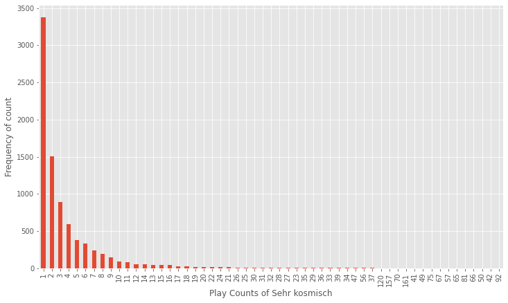

```python
#Plotting distributions of counts for interactions with song_id: SOFRQTD12A81C233C0 (Sehr kosmisch)

plt.figure(figsize=(12,7))

counts[counts['song_id'] == "SOFRQTD12A81C233C0"]['play_count'].value_counts().plot(kind='bar')
plt.xlabel('Play Counts of Sehr kosmisch')
plt.ylabel('Frequency of count')
plt.show()
```

We can see the majority of users who tried Sehr kosmisch played it once or twice, as the count of play count 1 and 2 is higher than the count of other play counts, which shows users switch easily and don't usually repeat playing this song.

### Data after dropping duplicates

```python
song.describe().T
```

|  | count | mean | std | min | 25% | 50% | 75% | max |
| --- | --- | --- | --- | --- | --- | --- | --- | --- |
| year | 999501.0 | 1029.950724 | 998.755026 | 0.0 | 0.0 | 1969.0 | 2002.0 | 2011.0 |

- Before this, we deleted 1 row in the beginning and 498 of the duplicate rows of the song dataframe later on, that's why instead of a million rows, we have 999,501 rows remaining.
- The observations start from year 0, which is obviously wrong.
- The last year in this dataframe is 2011.
- We'll investigate the year feature later on to see if its worth keeping or not.

```python
#The user who played the most songs in the dataset
counts['user_id'].value_counts()
```

```
6d625c6557df84b60d90426c0116138b617b9449    711
fbee1c8ce1a346fa07d2ef648cec81117438b91f    643
4e11f45d732f4861772b2906f81a7d384552ad12    556
24b98f8ab023f6e7a1c37c7729c623f7b821eb95    540
1aa4fd215aadb160965110ed8a829745cde319eb    533
                                           ...
1e787e398c974aad235244b6ae67f519cae3f0b1      1
aaec2e3ce85fcd9a59ea3709f39cb8c2e17ce2d4      1
af3a46c6e34412236cfb1737f556fb5851b0a873      1
338c5574838636fc0b43978031552d028a0ee668      1
ce21afc046f7708ede0b89733fe020bff579d3cb      1
Name: user_id, Length: 76353, dtype: int64
```

```python
counts['song_id'].nunique()
```

```
10000
```

The user with userId: 6d625c6557df84b60d90426c0116138b617b9449 has interacted with the most number of songs i.e. 711 songs. But still, there is a possibility of 10000-711 = 9289 more interactions as we have 10000 unique songs in our dataset. For those 9289 remaining songs, we can build a recommendation system to predict which songs are most likely to be played by this user.

The distribution of the user-song interactions in this dataset

```python
#Finding user-song interactions distribution

count_interactions = counts.groupby('user_id').count()['song_id']
count_interactions
```

```
user_id
00003a4459f33b92906be11abe0e93efc423c0ff     7
00005c6177188f12fb5e2e82cdbd93e8a3f35e64     5
00030033e3a2f904a48ec1dd53019c9969b6ef1f     9
0007235c769e610e3d339a17818a5708e41008d9    10
0007c0e74728ca9ef0fe4eb7f75732e8026a278b     9
                                            ..
fffce9c1537fbc350ea68823d956eaa8f5236dbe    44
fffd6a2bdef646ce9898b628d5dd56c43df69a9d    11
fffd9635b33f412de8ed02e44e6564e3644cf3c6    17
fffe6d1d8500f1c1f31bd63abce35c0f975a86bf     7
fffea3d509760c984e7d40789804c0e5e289cc86    23
Name: song_id, Length: 76353, dtype: int64
```

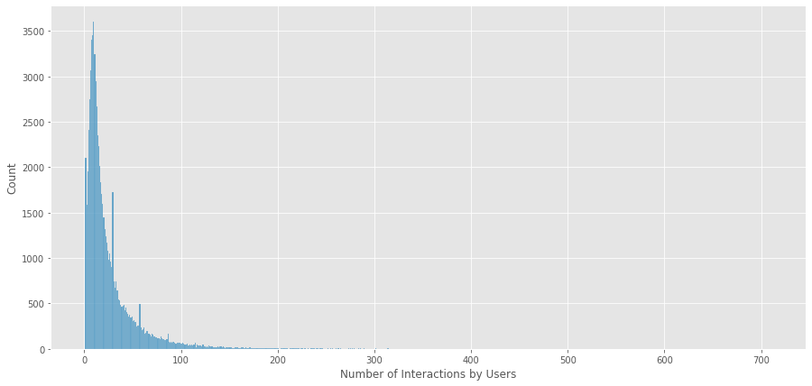

```python
#Plotting user-song interactions distribution

plt.figure(figsize=(15,7))

sns.histplot(count_interactions)

plt.xlabel('Number of Interactions by Users')

plt.show()
```

The distribution is skewed to the right. Only a few users interacted with more than 100 songs. As the below table shows, 50% of the observations are equal or below 16 interactions and 25% are above 31.

```python
count_interactions.describe()
```

```
count    76353.000000
mean        26.194125
std         31.625078
min          1.000000
25%          9.000000
50%         16.000000
75%         31.000000
max        711.000000
Name: song_id, dtype: float64
```

# Recommendation Systems

```python
# Merged Data
```

### Merge

Let's first merge both the datasets to get the title and number of plays of each song in a single dataframe, and then label the user_id and song_id to make them easier to use.

```python
#Merging datasets on sonf_id
plays_with_title = pd.merge(counts, song[['song_id', 'title']], on='song_id', how='inner')

plays_with_title.head()
```

|  | user_id | song_id | play_count | title |
| --- | --- | --- | --- | --- |
| 0 | b80344d063b5ccb3212f76538f3d9e43d87dca9e | SOAKIMP12A8C130995 | 1 | the cove |
| 1 | 7c86176941718984fed11b7c0674ff04c029b480 | SOAKIMP12A8C130995 | 1 | the cove |
| 2 | 76235885b32c4e8c82760c340dc54f9b608d7d7e | SOAKIMP12A8C130995 | 3 | the cove |
| 3 | 250c0fa2a77bc6695046e7c47882ecd85c42d748 | SOAKIMP12A8C130995 | 1 | the cove |
| 4 | 3f73f44560e822344b0fb7c6b463869743eb9860 | SOAKIMP12A8C130995 | 6 | the cove |

```python
plays_with_title['song_id'].nunique()
```

```
10000
```

```python
plays_with_title['user_id'].nunique()
```

```
76353
```

```python
plays_with_title.info()
```

```
<class 'pandas.core.frame.DataFrame'>
Int64Index: 2054534 entries, 0 to 2054533
Data columns (total 4 columns):
 #   Column      Dtype
---  ------      -----
 0   user_id     object
 1   song_id     object
 2   play_count  int64
 3   title       object
dtypes: int64(1), object(3)
memory usage: 78.4+ MB
```

- There are 2,054,534 observations and 4 columns in the data.
- All the columns are of object data type except the play_count column which is numeric.
- To ease our work with the dataset we will use label encodings to convert these two variables.

```python
#Label Encoding
le = LabelEncoder()

plays_with_title['user_id'] = le.fit_transform(plays_with_title['user_id'])

plays_with_title['song_id'] = le.fit_transform(plays_with_title['song_id'])
```

```python
plays_with_title.info()
```

```
<class 'pandas.core.frame.DataFrame'>
Int64Index: 2054534 entries, 0 to 2054533
Data columns (total 4 columns):
 #   Column      Dtype
---  ------      -----
 0   user_id     int32
 1   song_id     int32
 2   play_count  int64
 3   title       object
dtypes: int32(2), int64(1), object(1)
memory usage: 62.7+ MB
```

```python
plays_with_title.duplicated().sum()
```

```
43010
```

```python
# plays_with_title.drop_duplicates(inplace=True)
plays_with_title.drop_duplicates(subset=['user_id', 'song_id'],inplace=True)
```

```python
plays_with_title.info()
```

```
<class 'pandas.core.frame.DataFrame'>
Int64Index: 2000000 entries, 0 to 2054533
Data columns (total 4 columns):
 #   Column      Dtype
---  ------      -----
 0   user_id     int32
 1   song_id     int32
 2   play_count  int64
 3   title       object
dtypes: int32(2), int64(1), object(1)
memory usage: 61.0+ MB
```

```python
#checking for null values
plays_with_title.isnull().sum()
```

```
user_id       0
song_id       0
play_count    0
title         0
dtype: int64
```

```python
plays_with_title.head()
```

|  | user_id | song_id | play_count | title |
| --- | --- | --- | --- | --- |
| 0 | 54961 | 153 | 1 | the cove |
| 1 | 37056 | 153 | 1 | the cove |
| 2 | 35091 | 153 | 3 | the cove |
| 3 | 10905 | 153 | 1 | the cove |
| 4 | 18917 | 153 | 6 | the cove |

```python
df = pd.merge(counts, song.drop_duplicates(['song_id']), on="song_id", how="left")
```

```python
df.head()
```

|  | user_id | song_id | play_count | title | release | artist_name | year |
| --- | --- | --- | --- | --- | --- | --- | --- |
| 0 | b80344d063b5ccb3212f76538f3d9e43d87dca9e | SOAKIMP12A8C130995 | 1 | the cove | thicker than water | jack johnson | 0 |
| 1 | b80344d063b5ccb3212f76538f3d9e43d87dca9e | SOBBMDR12A8C13253B | 2 | entre dos aguas | flamenco para niños | paco de lucia | 1976 |
| 2 | b80344d063b5ccb3212f76538f3d9e43d87dca9e | SOBXHDL12A81C204C0 | 1 | stronger | graduation | kanye west | 2007 |
| 3 | b80344d063b5ccb3212f76538f3d9e43d87dca9e | SOBYHAJ12A6701BF1D | 1 | constellations | in between dreams | jack johnson | 2005 |
| 4 | b80344d063b5ccb3212f76538f3d9e43d87dca9e | SODACBL12A8C13C273 | 1 | learn to fly | there is nothing left to lose | foo fighters | 1999 |

```python
df.shape
```

```
(2000000, 7)
```

### Data Transformation

```python
# Summarize based on the number of times each song has been listened to:
df_agg = df.groupby(['title']).agg({'play_count': 'count'}).reset_index()
grouped_sum = df_agg['play_count'].sum()
df_agg['percentage']  = df_agg['play_count'].div(grouped_sum)*100
df_agg.sort_values(['play_count', 'title'], ascending = [0,1])
```

|  | title | play_count | percentage |
| --- | --- | --- | --- |
| 6831 | sehr kosmisch | 8277 | 0.41385 |
| 8726 | undo | 7032 | 0.35160 |
| 1961 | dog days are over (radio edit) | 6949 | 0.34745 |
| 9498 | you're the one | 6729 | 0.33645 |
| 6494 | revelry | 6145 | 0.30725 |
| ... | ... | ... | ... |
| 3360 | historia del portero | 51 | 0.00255 |
| 6777 | scared | 51 | 0.00255 |
| 2040 | don´t leave me now | 50 | 0.00250 |
| 2857 | ghosts (toxic avenger mix) | 48 | 0.00240 |
| 5565 | no creo en el jamas | 48 | 0.00240 |

9552 rows × 3 columns

```python
users = df['user_id'].unique()
len(users)
songs = df['title'].unique()
len(songs)
```

```
9552
```

### Split the data

```python
train_data, test_data = train_test_split(df, test_size = 0.20, random_state=42)
```

```python
train_data.head(2)
```

|  | user_id | song_id | play_count | title | release | artist_name | year |
| --- | --- | --- | --- | --- | --- | --- | --- |
| 399734 | e1b77dd8900cc0115a194ba3772356957e04ed3c | SOOGNOZ12AAF3B2936 | 14 | transparency | workout holiday | white denim | 2008 |
| 1750629 | ea388082bf29d7cf9af67dc33d9f939d10a1bdbf | SOLYQKS12A6D4FA42B | 2 | passenger (lp version) | white pony | deftones | 2000 |

```python
train_data.shape
```

```
(1600000, 7)
```

### Rank Based Recommendation System

This section provides recommendations based on the most popular items. This sort of recoomendation system is especially helpful when we want to recommend songs to the new users. We will use the Rank-Based Recommendation System to solve the cold start problem, so the best way to evaluate it would be to use it on new users and see the results or do A/B testing.

To build the rank-based recommendation system, we take average of all the play counts of each song and then rank them based on their average play hits.

```python
#Calculating average play counts for each song_id
average_counts = train_data.groupby('song_id').mean()['play_count']

#Calculating the count (number) of play counts for each song_id
count_counts = train_data.groupby('song_id').count()['play_count']

#Making a dataframe with the count and average of play counts
final_counts = pd.DataFrame({'avg_counts':average_counts, 'played_count':count_counts})
```

```python
final_counts.head(10)
```

| song_id | avg_counts | played_count |
| --- | --- | --- |
| SOAAAGQ12A8C1420C8 | 3.673077 | 52 |
| SOAACPJ12A81C21360 | 2.333333 | 120 |
| SOAACSG12AB018DC80 | 2.433962 | 53 |
| SOAAEJI12AB0188AB5 | 2.086957 | 46 |
| SOAAFAC12A67ADF7EB | 2.315436 | 149 |
| SOAAFYH12A8C13717A | 5.435185 | 108 |
| SOAAJMQ12A6D4F7D17 | 1.808824 | 68 |
| SOAAKPM12A58A77210 | 4.197183 | 71 |
| SOAALWN12A6D4F7FDA | 3.140000 | 50 |
| SOAAMOW12AB018149B | 1.507463 | 67 |

Next, create a function to find the top n songs for a recommendation based on the average counts of songs. We can also add a threshold for a minimum number of interactions for a song to be considered for recommendation.

```python
def top_n_songs(data, n=10, min_interaction=50):

    #Finding songs with minimum number of interactions
    recommendations = data[data['played_count'] > min_interaction]

    #Sorting values w.r.t average rating
    recommendations = recommendations.sort_values(by='avg_counts', ascending=False)

    return recommendations.index[:n]
```

Use the function top_n_songs with different n's and minimum interactions to get songs to recommend. Below, are some evamples:

```python
# Recommending top 10 songs with 250 minimum interactions based on popularity
[song[song['song_id'] ==i]['title'] for i in list(top_n_songs(final_counts, 10, 250))]
# list(top_n_songs(final_counts, 10, 250))
```

```
[797341    recado falado (metrô da saudade)
 Name: title, dtype: object, 32147    voices on a string (album version)
 Name: title, dtype: object, 133296    the big gundown
 Name: title, dtype: object, 805595    call it off (album version)
 Name: title, dtype: object, 531137    interactive halloween bear
 Name: title, dtype: object, 79528    reign of the tyrants
 Name: title, dtype: object, 920830    nine times out of ten (1998 digital remaster)
 Name: title, dtype: object, 448734    you're the one
 Name: title, dtype: object, 157892    sorrow (1997 digital remaster)
 Name: title, dtype: object, 301478    crumpshit
 Name: title, dtype: object]
```

```python
# Recommending top 10 songs with 500 minimum interactions based on popularity
[song[song['song_id'] ==i]['title'] for i in list(top_n_songs(final_counts, 10, 500))]
```

```
[448734    you're the one
 Name: title, dtype: object, 700827    make love to your mind
 Name: title, dtype: object, 111094    undo
 Name: title, dtype: object, 419205    invalid
 Name: title, dtype: object, 123574    hochmah (interlude)
 Name: title, dtype: object, 865239    revelry
 Name: title, dtype: object, 456754    it was a good day
 Name: title, dtype: object, 38412    brave the elements
 Name: title, dtype: object, 201863    ain't misbehavin
 Name: title, dtype: object, 785487    mercy:the laundromat
 Name: title, dtype: object]
```

### Hit rate

```python
# Calculate the number of times the recommended songs found in the test data were played in the test data
success = 0
for i in list(top_n_songs(final_counts, 10, 500)):
    success += len(test_data[test_data['song_id']==i])
print("The number of times the recommended songs found in the test data were played in the test data is",success,"times.")
```

```
The number of times the recommended songs found in the test data were played in the test data is 6196 times.
```

```python
# The percentage of times songs in the recommended list were played, compared to all unique songs played.
# Hit Rate = (HITS IN TEST) / (NUMBER OF USERS)
print("The percentage of users in the test dataset, who played the songs in the recommended list is",success/len(test_data['user_id'].unique())*100,'%')
```

```
The percentage of users in the test dataset, who played the songs in the recommended list is 9.042615294804436 %
```

Of course, although we haven't recommended the identified popular songs to anyone in the test data set, 9% of them have been listened in that set. Maybe we could assume that if we push our discovered songs and recommend users to play them, this percentage would increase.

### Collaborative Filtering Based Recommendation System

#### Types:

##### I- Similarity/Neighborhood based

#### I- Building Similarity/Neighborhood based Collaborative Filtering

First, create a user-item interactions matrix. Since this dataset is big, we will make a shorter version of this dataset by filtering to 1000 most rated songs and the top 1000 users who have interacted the most.

```python
#Finding IDs of top 1000 songs
top_1000_song = pd.DataFrame({'song_id':counts['song_id'].value_counts()[:1000].index})
top_1000_song.head()
```

|  | song_id |
| --- | --- |
| 0 | SOFRQTD12A81C233C0 |
| 1 | SOAUWYT12A81C206F1 |
| 2 | SOAXGDH12A8C13F8A1 |
| 3 | SOBONKR12A58A7A7E0 |
| 4 | SOSXLTC12AF72A7F54 |

```python
#Finding IDs of top 1000 users
top_1000_users = pd.DataFrame({'user_id':counts[counts['song_id'].isin(top_1000_song['song_id'])]['user_id'].value_counts()[:1000].index})
top_1000_users.head()
```

|  | user_id |
| --- | --- |
| 0 | ce5c912bb8044f23fc0fc31bd986b8d0a7303db5 |
| 1 | 0b19fe0fad7ca85693846f7dad047c449784647e |
| 2 | 34e191b5e3ac4d0b86b100e3325aa46c34998248 |
| 3 | 2078b23380f2a80615fb9829621f7dc6cc6c7a82 |
| 4 | 4e3398ef89d9c00975d0b0f5b7bc7b7f067c7902 |

```python
#Filtering the original data to contain only top 1000 songs
reviews_small = top_1000_song.merge(counts, how='inner', on='song_id')
reviews_small.shape
```

```
(768833, 3)
```

```python
#Filtering the data with top 1000 songs to contain only top 1000 users
reviews_small = top_1000_users.merge(reviews_small, how='inner', on='user_id')
reviews_small.shape
```

```
(89353, 3)
```

```python
reviews_small.head()
```

|  | user_id | song_id | play_count |
| --- | --- | --- | --- |
| 0 | ce5c912bb8044f23fc0fc31bd986b8d0a7303db5 | SOFRQTD12A81C233C0 | 1 |
| 1 | ce5c912bb8044f23fc0fc31bd986b8d0a7303db5 | SOAUWYT12A81C206F1 | 14 |
| 2 | ce5c912bb8044f23fc0fc31bd986b8d0a7303db5 | SOAXGDH12A8C13F8A1 | 3 |
| 3 | ce5c912bb8044f23fc0fc31bd986b8d0a7303db5 | SOBONKR12A58A7A7E0 | 13 |
| 4 | ce5c912bb8044f23fc0fc31bd986b8d0a7303db5 | SOSXLTC12AF72A7F54 | 8 |

#### user-item interactions matrix

```python
# compute the user-item interactions matrix
interactions_matrix = reviews_small.pivot(index='user_id', columns='song_id', values='play_count')
```

```python
#interactions_matrix = counts.pivot(index='user_id', columns='song_id', values='play_count')
# interactions_matrix = plays_with_title.pivot(index='user_id', columns='song_id', values='play_count')
interactions_matrix
```

| song_id user_id | SOAAVUV12AB0186646 | SOAAWEE12A6D4FBEC8 | SOABJBU12A8C13F63F | SOACIPG12A8AE47E1C | SOADISH12AB018DFAC | SOADJQJ12A8C141D38 | SOADOQJ12A8AE45C7E | SOADQPP12A67020C82 | SOAEHEX12A8C13EFA4 | SOAEYBP12AB0184573 | ... | SOZPLKR12A6D4F8421 | SOZRIFX12A8C142691 | SOZSFWF12A6D4F93D5 | SOZSZTY12A8C13B693 | SOZVCRW12A67ADA0B7 | SOZVUCT12A8C1424BE | SOZVVRE12A8C143150 | SOZXEZV12A6D4F737F | SOZYDZR12A8C13F4F0 | SOZYSDT12A8C13BFD7 |
| --- | --- | --- | --- | --- | --- | --- | --- | --- | --- | --- | --- | --- | --- | --- | --- | --- | --- | --- | --- | --- | --- |
| 00544d8bde0d7985e8d703c1eb676d41cad33c67 | 1.0 | NaN | NaN | NaN | NaN | NaN | NaN | NaN | NaN | NaN | ... | NaN | NaN | NaN | NaN | NaN | NaN | 1.0 | NaN | NaN | NaN |
| 009fab78deabfd28481ce0123f5a9894c094d971 | NaN | NaN | 2.0 | NaN | NaN | NaN | NaN | NaN | NaN | NaN | ... | NaN | NaN | NaN | NaN | 3.0 | 1.0 | NaN | NaN | NaN | NaN |
| 01333e5ccca2ce6b6c476b599d8c95566b6b4e78 | NaN | NaN | NaN | NaN | NaN | NaN | NaN | 2.0 | NaN | NaN | ... | NaN | NaN | NaN | NaN | 1.0 | NaN | NaN | NaN | NaN | NaN |
| 013b05f19d72d665b37026b8e5ff6d19a4b9d0b9 | NaN | NaN | NaN | NaN | NaN | 2.0 | NaN | NaN | NaN | NaN | ... | NaN | NaN | NaN | NaN | NaN | 1.0 | NaN | NaN | NaN | NaN |
| 018a9cd406ed6cf3e2e59da62fdb656144b4db9c | 4.0 | NaN | NaN | NaN | NaN | 4.0 | NaN | NaN | NaN | 4.0 | ... | NaN | NaN | NaN | NaN | 1.0 | NaN | NaN | NaN | NaN | NaN |
| ... | ... | ... | ... | ... | ... | ... | ... | ... | ... | ... | ... | ... | ... | ... | ... | ... | ... | ... | ... | ... | ... |
| ff753593746245c03b354e126e14cbf7086adffb | NaN | NaN | NaN | NaN | NaN | NaN | NaN | NaN | NaN | NaN | ... | NaN | NaN | NaN | NaN | NaN | NaN | NaN | NaN | NaN | NaN |
| ff75f58dff87e9f9f767134882e515e75cd94dde | NaN | NaN | NaN | NaN | NaN | NaN | 1.0 | NaN | NaN | NaN | ... | NaN | NaN | NaN | NaN | 1.0 | NaN | NaN | NaN | NaN | NaN |
| ff7ac60d58cd4ac90bad9166f49712956deaca88 | NaN | NaN | NaN | NaN | NaN | NaN | NaN | NaN | NaN | NaN | ... | NaN | NaN | NaN | NaN | 1.0 | NaN | NaN | NaN | NaN | NaN |
| ffc564b85d81f0ea427cee3eea2415cc2fc5c4be | NaN | NaN | NaN | NaN | NaN | 1.0 | NaN | NaN | NaN | NaN | ... | NaN | NaN | NaN | NaN | NaN | NaN | NaN | NaN | NaN | NaN |
| ffd458f903d49854685cf4540245c1d297e8bafa | NaN | NaN | NaN | NaN | NaN | NaN | NaN | NaN | NaN | NaN | ... | NaN | NaN | NaN | NaN | 1.0 | NaN | NaN | NaN | NaN | NaN |

1000 rows × 1000 columns

```python
# This is a very sparse matrix. We will find out the most similar users using this matrix.
# Calculate pairwise cosine similarities for all users.
# Notice that Cosine similarity can't take missing values in its vectors,
# hence we need to fill those NaN values with some value, like zero or in some cases mean (here 0 is more realistic)
```

```python
interactions_matrix.fillna(0, inplace=True)
interactions_matrix.head()
```

| song_id user_id | SOAAVUV12AB0186646 | SOAAWEE12A6D4FBEC8 | SOABJBU12A8C13F63F | SOACIPG12A8AE47E1C | SOADISH12AB018DFAC | SOADJQJ12A8C141D38 | SOADOQJ12A8AE45C7E | SOADQPP12A67020C82 | SOAEHEX12A8C13EFA4 | SOAEYBP12AB0184573 | ... | SOZPLKR12A6D4F8421 | SOZRIFX12A8C142691 | SOZSFWF12A6D4F93D5 | SOZSZTY12A8C13B693 | SOZVCRW12A67ADA0B7 | SOZVUCT12A8C1424BE | SOZVVRE12A8C143150 | SOZXEZV12A6D4F737F | SOZYDZR12A8C13F4F0 | SOZYSDT12A8C13BFD7 |
| --- | --- | --- | --- | --- | --- | --- | --- | --- | --- | --- | --- | --- | --- | --- | --- | --- | --- | --- | --- | --- | --- |
| 00544d8bde0d7985e8d703c1eb676d41cad33c67 | 1.0 | 0.0 | 0.0 | 0.0 | 0.0 | 0.0 | 0.0 | 0.0 | 0.0 | 0.0 | ... | 0.0 | 0.0 | 0.0 | 0.0 | 0.0 | 0.0 | 1.0 | 0.0 | 0.0 | 0.0 |
| 009fab78deabfd28481ce0123f5a9894c094d971 | 0.0 | 0.0 | 2.0 | 0.0 | 0.0 | 0.0 | 0.0 | 0.0 | 0.0 | 0.0 | ... | 0.0 | 0.0 | 0.0 | 0.0 | 3.0 | 1.0 | 0.0 | 0.0 | 0.0 | 0.0 |
| 01333e5ccca2ce6b6c476b599d8c95566b6b4e78 | 0.0 | 0.0 | 0.0 | 0.0 | 0.0 | 0.0 | 0.0 | 2.0 | 0.0 | 0.0 | ... | 0.0 | 0.0 | 0.0 | 0.0 | 1.0 | 0.0 | 0.0 | 0.0 | 0.0 | 0.0 |
| 013b05f19d72d665b37026b8e5ff6d19a4b9d0b9 | 0.0 | 0.0 | 0.0 | 0.0 | 0.0 | 2.0 | 0.0 | 0.0 | 0.0 | 0.0 | ... | 0.0 | 0.0 | 0.0 | 0.0 | 0.0 | 1.0 | 0.0 | 0.0 | 0.0 | 0.0 |
| 018a9cd406ed6cf3e2e59da62fdb656144b4db9c | 4.0 | 0.0 | 0.0 | 0.0 | 0.0 | 4.0 | 0.0 | 0.0 | 0.0 | 4.0 | ... | 0.0 | 0.0 | 0.0 | 0.0 | 1.0 | 0.0 | 0.0 | 0.0 | 0.0 | 0.0 |

5 rows × 1000 columns

Now, let's create a function to find similar users and similarity scores for given userID and interaction matrix. We can use this function to find similar users for different user IDs

```python
def similar_users(user_id, interactions_matrix):
    similarity = []
    for user in interactions_matrix.index:#for user in range(1, interactions_matrix.shape[0]+1):

        #finding cosine similarity between the user_id and each user
        sim = cosine_similarity([interactions_matrix.loc[user_id]], [interactions_matrix.loc[user]])

        #Appending the user and the corresponding similarity score with user_id as a tuple
        similarity.append((user, sim))

    similarity.sort(key=lambda x: x[1], reverse=True)   #Sorting the list on the basis of similarity scores

    most_similar_users = [tup[0] for tup in similarity] #Extracting the user from each tuple in the sorted list

    similarity_score = [tup[1] for tup in similarity]   #Extracting the similarity score from each tuple in the sorted list

    most_similar_users.remove(user_id)                  #Removing the original user and keeping only other similar users
    similarity_score.remove(similarity_score[0])

    return most_similar_users, similarity_score
```

```python
# Example
# Previously, we found that userId 6d625c6557df84b60d90426c0116138b617b9449 has interacted with the most number of songs
# Now, let's identify top 10 similar users to the userID 6d625c6557df84b60d90426c0116138b617b9449 and their similarity score
similar_users("6d625c6557df84b60d90426c0116138b617b9449", interactions_matrix)[0][:10]
```

```
['dfc73b970c62e7198104cbb6f39b09cc658daba9',
 'cfa8f1c9546fd9fcfe33895236ff8eb8a34a1c32',
 'eb58cae803ed9393b0f415596592b7012c93c345',
 '551918ad69a336eb5c21713b00d70502faa187cb',
 'a08845ff06fbe719c242ce88cab3fcd045e71cdc',
 'e9c2ad65dca02fdc7de00b93941338880a114fe2',
 '9114f227a089efc58480b525699ca9b6d1e71ff3',
 '667d23e75ed4da9108a01a3e43663e302e84e9e3',
 'd4f673fcab81af5ca195c47d119a9dce54cc52a0',
 'bc558cf51adb5c3e8546e8cb1f7dfa442146fd2c']
```

```python
# scores
similar_users("6d625c6557df84b60d90426c0116138b617b9449", interactions_matrix)[1][:10]
```

```
[array([[0.4555368]]),
 array([[0.41706887]]),
 array([[0.39506407]]),
 array([[0.37890808]]),
 array([[0.37089686]]),
 array([[0.36180944]]),
 array([[0.35561976]]),
 array([[0.33717921]]),
 array([[0.33108793]]),
 array([[0.32881458]])]
```

Up to now, we have learned how to find similar users for a given user. Next, we'll find which songs to recommend to a particular user. This is done by finding the songs which have been interacted most by similar users but not by the user of interest.

```python
def recommendations(user_id, num_of_songs, interactions_matrix, reviews_small):

    #Saving similar users using the function similar_users defined above
    most_similar_users = similar_users(user_id, interactions_matrix)[0]

    #Finding song IDs with which the user_id has interacted
    song_ids = set(interactions_matrix.columns[np.where(interactions_matrix.loc[user_id] > 0)])#no need to list
    recommendations = []

    observed_interactions = song_ids.copy()
    for similar_user in most_similar_users:
        if len(recommendations) < num_of_songs:
            #Finding 'n' songs which have been rated by similar users but not by the user_id
            similar_user_song_ids = set(interactions_matrix.columns[np.where(interactions_matrix.loc[similar_user] > 0)])#no need to list
            recommendations.extend(list(similar_user_song_ids.difference(observed_interactions)))
            observed_interactions = observed_interactions.union(similar_user_song_ids)
        else:
            break

    song_names = song[song['song_id'].isin(recommendations[:num_of_songs])]['title'].unique()
    return song_names
```

```python
# Example
# 10 recommendations for user id: 'dfc73b970c62e7198104cbb6f39b09cc658daba9'
recommendations('dfc73b970c62e7198104cbb6f39b09cc658daba9', 10, interactions_matrix, reviews_small)
```

```
array(['paper planes', 'map of the problematique',
       'my boy builds coffins', 'from the station', 'yellow', 'mia',
       'black hole sun', 'frank sinatra', 'alejandro',
       'they might follow you'], dtype=object)
```

#### II- Model Based Collaborative Filtering - Matrix Factorization

Model-based Collaborative Filtering is a personalized recommendation system, the recommendations are based on the past behavior of the user and it is not dependent on any additional information. We use latent features to find recommendations for each user.

SVD is used to compute the latent features from the user-item matrix that we already learned earlier. We can find the decomposition using the svd() function from the linalg module of the NumPy library.

```python
u, s, vt = np.linalg.svd(interactions_matrix, full_matrices=False)
```

```python
u.shape, s.shape, vt.shape
```

```
((1000, 1000), (1000,), (1000, 1000))
```

Now, we need to find the appropriate K to use in order to re-generate the interaction matrix and make predictions. We will split the data into train and test data and make predictions for different value of K. We will choose the K which gives good performance on the train and test data.

```python
# Split the data into train and test data
X_train, X_test = train_test_split(reviews_small, test_size=0.2, random_state=42)
```

```python
X_train.shape, X_test.shape
```

```
((71482, 3), (17871, 3))
```

```python
#Train interaction matrix
interactions_matrix_train = X_train.pivot(index='user_id', columns='song_id', values='play_count')
interactions_matrix_train.fillna(0, inplace=True)
```

```python
interactions_matrix_train.shape
```

```
(1000, 1000)
```

```python
#Test interaction matrix
interactions_matrix_test = X_test.pivot(index='user_id', columns='song_id', values='play_count')
interactions_matrix_test.fillna(0, inplace=True)
```

```python
interactions_matrix_test.shape
```

```
(1000, 995)
```

We will use the interactions_matrix_train to find U, S, and V transpose using SVD. Then find the subset of rows in the interactions_matrix_test dataset which we can predict using this matrix decomposition with different numbers of latent features.

```python
#Finding unique users in train and test data and then taking their intersection (common users)
train_idx = set(interactions_matrix_train.index)
test_idx = set(interactions_matrix_test.index)
match_idx = train_idx.intersection(test_idx)

#Finding unique songs in train and test data and then taking their intersection
train_song = set(interactions_matrix_train.columns)
test_song = set(interactions_matrix_test.columns)
match_cols = train_song.intersection(test_song)

#Selecting only common users and songs from the test interaction matrix
interactions_matrix_test = interactions_matrix_test.loc[match_idx, match_cols]
```

```python
interactions_matrix_test.shape
```

```
(1000, 995)
```

Now, let's decompose the interactions_matrix_train and find the U and Vt for the test data using the common users and songs in the train and test data

```python
u_train, s_train, vt_train = np.linalg.svd(interactions_matrix_train, full_matrices=False)
```

```python
#Finding u_test and vt_test matrices using u_train, vt_train and common user/song in train and test data
row_idxs = interactions_matrix_train.index.isin(test_idx)
col_idxs = interactions_matrix_train.columns.isin(test_song)
u_test = u_train[row_idxs, :]
vt_test = vt_train[:, col_idxs]
```

We have calculated U and Vt matrices for the train as well as test data. Now, we need to find the number of latent features that give us the lowest RMSE on the train and the test data.

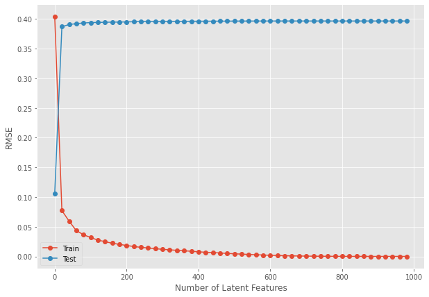

```python
#Creating array for number of latent features and empty lists to store train and test errors
latent_features = np.arange(0, 1000, 20)
train_error = []
test_error = []

for k in latent_features:
    #Slicing the U, S, and Vt matrices to get k latent features from train and test data
    s_train_lat, u_train_lat, vt_train_lat = np.diag(s_train[:k]), u_train[:, :k], vt_train[:k, :]
    u_test_lat, vt_test_lat = u_test[:, :k], vt_test[:k, :]

    #train and test interaction matrices using k latent features
    interactions_matrix_train_preds = np.around(np.matmul(np.matmul(u_train_lat, s_train_lat), vt_train_lat))
    interactions_matrix_test_preds = np.around(np.matmul(np.matmul(u_test_lat, s_train_lat), vt_test_lat))

    #Calculating the actual and predicted average plays for each song in the training data
    avg_play_train = interactions_matrix_train.mean(axis=0)
    avg_play_train_pred = interactions_matrix_train_preds.mean(axis=0)

    #Calculating the actual and predicted average plays for each song in the test data
    avg_play_test = interactions_matrix_test.mean(axis=0)
    avg_play_test_pred = interactions_matrix_test_preds.mean(axis=0)

    #Calculating train and test RMSE
    train_rmse = mean_squared_error(avg_play_train, avg_play_train_pred, squared=False)
    test_rmse = mean_squared_error(avg_play_test, avg_play_test_pred, squared=False)

    train_error.append(train_rmse)
    test_error.append(test_rmse)

#Plotting train and test RMSE
plt.figure(figsize=(10,7))
plt.plot(latent_features, train_error, label='Train', marker='o');
plt.plot(latent_features, test_error, label='Test', marker='o');
plt.xlabel('Number of Latent Features');
plt.ylabel('RMSE');
plt.legend();
```

```python
#reconstruct the original interaction matrix using latent features = 10
s_final, u_final, vt_final = np.diag(s[:10]), u[:, :10], vt[:10, :]
song_predicted_plays = np.around(np.matmul(np.matmul(u_final, s_final), vt_final))
song_predicted_plays = pd.DataFrame(abs(song_predicted_plays), columns = interactions_matrix.columns, index = interactions_matrix.index)
song_predicted_plays.head()
```

| song_id user_id | SOAAVUV12AB0186646 | SOAAWEE12A6D4FBEC8 | SOABJBU12A8C13F63F | SOACIPG12A8AE47E1C | SOADISH12AB018DFAC | SOADJQJ12A8C141D38 | SOADOQJ12A8AE45C7E | SOADQPP12A67020C82 | SOAEHEX12A8C13EFA4 | SOAEYBP12AB0184573 | ... | SOZPLKR12A6D4F8421 | SOZRIFX12A8C142691 | SOZSFWF12A6D4F93D5 | SOZSZTY12A8C13B693 | SOZVCRW12A67ADA0B7 | SOZVUCT12A8C1424BE | SOZVVRE12A8C143150 | SOZXEZV12A6D4F737F | SOZYDZR12A8C13F4F0 | SOZYSDT12A8C13BFD7 |
| --- | --- | --- | --- | --- | --- | --- | --- | --- | --- | --- | --- | --- | --- | --- | --- | --- | --- | --- | --- | --- | --- |
| 00544d8bde0d7985e8d703c1eb676d41cad33c67 | 0.0 | 0.0 | 0.0 | 0.0 | 0.0 | 0.0 | 0.0 | 0.0 | 0.0 | 0.0 | ... | 0.0 | 0.0 | 0.0 | 0.0 | 0.0 | 0.0 | 1.0 | 0.0 | 0.0 | 0.0 |
| 009fab78deabfd28481ce0123f5a9894c094d971 | 0.0 | 0.0 | 1.0 | 0.0 | 0.0 | 2.0 | 0.0 | 0.0 | 0.0 | 0.0 | ... | 0.0 | 0.0 | 0.0 | 0.0 | 2.0 | 1.0 | 0.0 | 0.0 | 0.0 | 0.0 |
| 01333e5ccca2ce6b6c476b599d8c95566b6b4e78 | 0.0 | 0.0 | 0.0 | 0.0 | 0.0 | 0.0 | 0.0 | 0.0 | 0.0 | 0.0 | ... | 0.0 | 0.0 | 0.0 | 0.0 | 0.0 | 0.0 | 2.0 | 0.0 | 0.0 | 0.0 |
| 013b05f19d72d665b37026b8e5ff6d19a4b9d0b9 | 0.0 | 0.0 | 0.0 | 0.0 | 0.0 | 1.0 | 0.0 | 0.0 | 0.0 | 0.0 | ... | 0.0 | 0.0 | 0.0 | 0.0 | 1.0 | 0.0 | 0.0 | 0.0 | 0.0 | 0.0 |
| 018a9cd406ed6cf3e2e59da62fdb656144b4db9c | 0.0 | 0.0 | 1.0 | 0.0 | 0.0 | 2.0 | 0.0 | 0.0 | 0.0 | 0.0 | ... | 0.0 | 0.0 | 0.0 | 0.0 | 3.0 | 1.0 | 1.0 | 0.0 | 0.0 | 0.0 |

5 rows × 1000 columns

```python
# create a function to recommend songs to the users on the basis of highest predicted plays for each song
def recommend_song(user_idx, interactions_matrix, preds_df, num_recommendations):

    # Get and sort stars given by users from the actual and predicted interaction matrix
    sorted_user_plays = interactions_matrix.loc[user_idx].sort_values(ascending=False)
    sorted_user_predictions = preds_df.loc[user_idx].sort_values(ascending=False)

    #Creating a dataframe with actual and predicted plays columns
    temp = pd.concat([sorted_user_plays, sorted_user_predictions], axis=1)
    temp.index.name = 'Recommended song'
    temp.columns = ['user_plays', 'user_predictions']

    #Filtering the dataframe where actual plays are 0 which implies that the user has not interacted with that song
    temp = temp.loc[temp.user_plays == 0]

    #Recommending songs with top predicted plays
    temp = temp.sort_values('user_predictions', ascending=False)
    print('\nBelow are the recommended songs for user(user_id = {}):\n'.format(user_index))
    print(temp['user_predictions'].head(num_recommendations))
```

```python
# Recommend songs to a user
user_index = '00544d8bde0d7985e8d703c1eb676d41cad33c67'
num_recommendations = 10
recommend_song(user_index, interactions_matrix, song_predicted_plays, num_recommendations)
# song[song['song_id'].isin(recommendations[:num_of_songs])]['title'].unique()
```

```
Below are the recommended songs for user(user_id = 00544d8bde0d7985e8d703c1eb676d41cad33c67):

Recommended song
SOPSOHT12A67AE0235    3.0
SOXLOQG12AF72A2D55    2.0
SOWEHOM12A6BD4E09E    2.0
SOVIZNF12AF72A710A    2.0
SONQCXC12A6D4F6A37    2.0
SORJICW12A8C13640D    2.0
SODCNJX12A6D4F93CB    2.0
SOOFYTN12A6D4F9B35    2.0
SOTCMDJ12A6D4F8528    2.0
SOMYXWV12A8C14232E    1.0
Name: user_predictions, dtype: float64
```

Evaluation

```python
#creating a dataframe containing average actual plays and avearge predicted plays of the song
rmse_df = pd.concat([interactions_matrix.mean(), song_predicted_plays.mean()], axis=1)
rmse_df.columns = ['Avg_actual_plays', 'Avg_predicted_plays']
rmse_df
```

| song_id | Avg_actual_plays | Avg_predicted_plays |
| --- | --- | --- |
| SOAAVUV12AB0186646 | 0.159 | 0.017 |
| SOAAWEE12A6D4FBEC8 | 0.042 | 0.000 |
| SOABJBU12A8C13F63F | 0.374 | 0.192 |
| SOACIPG12A8AE47E1C | 0.060 | 0.003 |
| SOADISH12AB018DFAC | 0.129 | 0.055 |
| ... | ... | ... |
| SOZVUCT12A8C1424BE | 0.407 | 0.292 |
| SOZVVRE12A8C143150 | 1.114 | 1.133 |
| SOZXEZV12A6D4F737F | 0.056 | 0.000 |
| SOZYDZR12A8C13F4F0 | 0.075 | 0.001 |
| SOZYSDT12A8C13BFD7 | 0.149 | 0.011 |

1000 rows × 2 columns

```python
RMSE = mean_squared_error(rmse_df['Avg_actual_plays'], rmse_df['Avg_predicted_plays'], squared=False)
print('\nRMSE SVD Model = {} \n'.format(RMSE))
```

```
RMSE SVD Model = 0.10785507869358772
```

- The RMSE is low which implies that the majority of predicted play counts are close to the actual play counts

### Clustering Based Recommendation System

In clustering-based recommendation systems, we explore the similarities and differences in people's tastes in songs based on how much they play different songs. We cluster similar users together and recommend songs to a user based on play counts from other users in the same cluster.

Here, we will use the user-item interactions matrix we defined earlier (while we were doing Similarity/Neighborhood based Collaborative Filtering).

```python
interactions_matrix
```

| song_id user_id | SOAAVUV12AB0186646 | SOAAWEE12A6D4FBEC8 | SOABJBU12A8C13F63F | SOACIPG12A8AE47E1C | SOADISH12AB018DFAC | SOADJQJ12A8C141D38 | SOADOQJ12A8AE45C7E | SOADQPP12A67020C82 | SOAEHEX12A8C13EFA4 | SOAEYBP12AB0184573 | ... | SOZPLKR12A6D4F8421 | SOZRIFX12A8C142691 | SOZSFWF12A6D4F93D5 | SOZSZTY12A8C13B693 | SOZVCRW12A67ADA0B7 | SOZVUCT12A8C1424BE | SOZVVRE12A8C143150 | SOZXEZV12A6D4F737F | SOZYDZR12A8C13F4F0 | SOZYSDT12A8C13BFD7 |
| --- | --- | --- | --- | --- | --- | --- | --- | --- | --- | --- | --- | --- | --- | --- | --- | --- | --- | --- | --- | --- | --- |
| 00544d8bde0d7985e8d703c1eb676d41cad33c67 | 1.0 | 0.0 | 0.0 | 0.0 | 0.0 | 0.0 | 0.0 | 0.0 | 0.0 | 0.0 | ... | 0.0 | 0.0 | 0.0 | 0.0 | 0.0 | 0.0 | 1.0 | 0.0 | 0.0 | 0.0 |
| 009fab78deabfd28481ce0123f5a9894c094d971 | 0.0 | 0.0 | 2.0 | 0.0 | 0.0 | 0.0 | 0.0 | 0.0 | 0.0 | 0.0 | ... | 0.0 | 0.0 | 0.0 | 0.0 | 3.0 | 1.0 | 0.0 | 0.0 | 0.0 | 0.0 |
| 01333e5ccca2ce6b6c476b599d8c95566b6b4e78 | 0.0 | 0.0 | 0.0 | 0.0 | 0.0 | 0.0 | 0.0 | 2.0 | 0.0 | 0.0 | ... | 0.0 | 0.0 | 0.0 | 0.0 | 1.0 | 0.0 | 0.0 | 0.0 | 0.0 | 0.0 |
| 013b05f19d72d665b37026b8e5ff6d19a4b9d0b9 | 0.0 | 0.0 | 0.0 | 0.0 | 0.0 | 2.0 | 0.0 | 0.0 | 0.0 | 0.0 | ... | 0.0 | 0.0 | 0.0 | 0.0 | 0.0 | 1.0 | 0.0 | 0.0 | 0.0 | 0.0 |
| 018a9cd406ed6cf3e2e59da62fdb656144b4db9c | 4.0 | 0.0 | 0.0 | 0.0 | 0.0 | 4.0 | 0.0 | 0.0 | 0.0 | 4.0 | ... | 0.0 | 0.0 | 0.0 | 0.0 | 1.0 | 0.0 | 0.0 | 0.0 | 0.0 | 0.0 |
| ... | ... | ... | ... | ... | ... | ... | ... | ... | ... | ... | ... | ... | ... | ... | ... | ... | ... | ... | ... | ... | ... |
| ff753593746245c03b354e126e14cbf7086adffb | 0.0 | 0.0 | 0.0 | 0.0 | 0.0 | 0.0 | 0.0 | 0.0 | 0.0 | 0.0 | ... | 0.0 | 0.0 | 0.0 | 0.0 | 0.0 | 0.0 | 0.0 | 0.0 | 0.0 | 0.0 |
| ff75f58dff87e9f9f767134882e515e75cd94dde | 0.0 | 0.0 | 0.0 | 0.0 | 0.0 | 0.0 | 1.0 | 0.0 | 0.0 | 0.0 | ... | 0.0 | 0.0 | 0.0 | 0.0 | 1.0 | 0.0 | 0.0 | 0.0 | 0.0 | 0.0 |
| ff7ac60d58cd4ac90bad9166f49712956deaca88 | 0.0 | 0.0 | 0.0 | 0.0 | 0.0 | 0.0 | 0.0 | 0.0 | 0.0 | 0.0 | ... | 0.0 | 0.0 | 0.0 | 0.0 | 1.0 | 0.0 | 0.0 | 0.0 | 0.0 | 0.0 |
| ffc564b85d81f0ea427cee3eea2415cc2fc5c4be | 0.0 | 0.0 | 0.0 | 0.0 | 0.0 | 1.0 | 0.0 | 0.0 | 0.0 | 0.0 | ... | 0.0 | 0.0 | 0.0 | 0.0 | 0.0 | 0.0 | 0.0 | 0.0 | 0.0 | 0.0 |
| ffd458f903d49854685cf4540245c1d297e8bafa | 0.0 | 0.0 | 0.0 | 0.0 | 0.0 | 0.0 | 0.0 | 0.0 | 0.0 | 0.0 | ... | 0.0 | 0.0 | 0.0 | 0.0 | 1.0 | 0.0 | 0.0 | 0.0 | 0.0 | 0.0 |

1000 rows × 1000 columns

```python
reviews_small.shape
```

```
(89353, 3)
```

```python
def find_most_played_songs(interactions_matrix, num_songs):

    #Appending the count of plays for each song as a row in the interaction matrix
    user_song_plays = interactions_matrix.append(interactions_matrix.count(), ignore_index=True)

    #Sorting the values in the interaction matrix on the basis of the appended row
    user_song_plays_sorted = user_song_plays.sort_values(len(user_song_plays)-1, axis=1, ascending=False)

    #Dropping the appended row from the sorted interaction matrix
    user_song_plays_sorted = user_song_plays_sorted.drop(user_song_plays_sorted.tail(1).index)

    #Selecting top songs with the most number of plays
    most_played_songs = user_song_plays_sorted.iloc[:, :num_songs]

    return most_played_songs
```

```python
#Finding 30 most played songs
most_played_songs = find_most_played_songs(interactions_matrix, 30)
most_played_songs
```

| song_id | SOAAVUV12AB0186646 | SORKVID12A6D4FC6D2 | SORAHAG12AB0182BD0 | SORALYQ12A8151BA99 | SORBBFV12AB017D710 | SOREBOB12A6D4F7986 | SOREDMW12AB01871BB | SOREPNQ12A58A7B49E | SORFVMQ12AB0184135 | SORGVYS12A8AE48882 | ... | SORRYFP12A8C13A08D | SORTDSD12A6D4F798B | SORUFVF12AB018230B | SORVLRC12A8151E078 | SORWLJM12A6D4F9C0C | SORWLTW12A670208FA | SORYLNP12A8C13C3E7 | SORZCTH12A6D4FB0BD | SOSACAB12AB01876E4 | SOSBKKN12A8C1384B4 |
| --- | --- | --- | --- | --- | --- | --- | --- | --- | --- | --- | --- | --- | --- | --- | --- | --- | --- | --- | --- | --- | --- |
| 0 | 1.0 | 0.0 | 0.0 | 0.0 | 0.0 | 0.0 | 0.0 | 0.0 | 0.0 | 0.0 | ... | 0.0 | 0.0 | 0.0 | 0.0 | 0.0 | 0.0 | 0.0 | 0.0 | 0.0 | 0.0 |
| 1 | 0.0 | 0.0 | 0.0 | 1.0 | 3.0 | 0.0 | 0.0 | 0.0 | 0.0 | 0.0 | ... | 0.0 | 0.0 | 1.0 | 0.0 | 0.0 | 0.0 | 0.0 | 0.0 | 0.0 | 0.0 |
| 2 | 0.0 | 0.0 | 0.0 | 0.0 | 0.0 | 0.0 | 0.0 | 0.0 | 0.0 | 0.0 | ... | 0.0 | 0.0 | 0.0 | 0.0 | 0.0 | 0.0 | 0.0 | 0.0 | 0.0 | 0.0 |
| 3 | 0.0 | 0.0 | 0.0 | 1.0 | 0.0 | 0.0 | 0.0 | 0.0 | 0.0 | 0.0 | ... | 0.0 | 0.0 | 0.0 | 0.0 | 0.0 | 0.0 | 0.0 | 0.0 | 0.0 | 0.0 |
| 4 | 4.0 | 0.0 | 0.0 | 0.0 | 0.0 | 0.0 | 0.0 | 0.0 | 0.0 | 0.0 | ... | 0.0 | 0.0 | 0.0 | 0.0 | 0.0 | 5.0 | 0.0 | 0.0 | 0.0 | 0.0 |
| ... | ... | ... | ... | ... | ... | ... | ... | ... | ... | ... | ... | ... | ... | ... | ... | ... | ... | ... | ... | ... | ... |
| 995 | 0.0 | 0.0 | 0.0 | 0.0 | 0.0 | 0.0 | 0.0 | 0.0 | 0.0 | 0.0 | ... | 0.0 | 0.0 | 0.0 | 0.0 | 0.0 | 0.0 | 0.0 | 0.0 | 0.0 | 0.0 |
| 996 | 0.0 | 0.0 | 0.0 | 0.0 | 0.0 | 0.0 | 0.0 | 0.0 | 0.0 | 0.0 | ... | 4.0 | 0.0 | 0.0 | 1.0 | 0.0 | 0.0 | 0.0 | 0.0 | 0.0 | 2.0 |
| 997 | 0.0 | 0.0 | 0.0 | 0.0 | 0.0 | 0.0 | 0.0 | 0.0 | 0.0 | 0.0 | ... | 0.0 | 0.0 | 0.0 | 0.0 | 0.0 | 1.0 | 0.0 | 4.0 | 0.0 | 0.0 |
| 998 | 0.0 | 0.0 | 0.0 | 0.0 | 0.0 | 0.0 | 0.0 | 0.0 | 0.0 | 0.0 | ... | 0.0 | 0.0 | 0.0 | 0.0 | 0.0 | 0.0 | 0.0 | 0.0 | 0.0 | 0.0 |
| 999 | 0.0 | 0.0 | 0.0 | 0.0 | 0.0 | 0.0 | 0.0 | 0.0 | 1.0 | 0.0 | ... | 0.0 | 0.0 | 0.0 | 0.0 | 0.0 | 0.0 | 0.0 | 0.0 | 0.0 | 0.0 |

1000 rows × 30 columns

```python
def find_most_interacted_users(most_played_songs, num_users):

    #Finding how many of the top 10 songs have been played by the user
    most_played_songs['counts'] = pd.Series(most_played_songs.count(axis=1))

    #Sorting the dataframe by the new 'counts' columns
    most_played_songs_users = most_played_songs.sort_values('counts', ascending=False)

    #Selecting top users with the most number of interactions
    most_played_songs_users_selected = most_played_songs_users.iloc[:num_users, :]

    #Dropping the 'counts' column
    most_played_songs_users_selected.drop(['counts'], axis=1, inplace=True)

    return most_played_songs_users_selected
```

```python
#Finding top 18 users with the most number of interactions
most_played_songs_users_selected = find_most_interacted_users(most_played_songs, 18)
most_played_songs_users_selected
```

| song_id | SOAAVUV12AB0186646 | SORKVID12A6D4FC6D2 | SORAHAG12AB0182BD0 | SORALYQ12A8151BA99 | SORBBFV12AB017D710 | SOREBOB12A6D4F7986 | SOREDMW12AB01871BB | SOREPNQ12A58A7B49E | SORFVMQ12AB0184135 | SORGVYS12A8AE48882 | ... | SORRYFP12A8C13A08D | SORTDSD12A6D4F798B | SORUFVF12AB018230B | SORVLRC12A8151E078 | SORWLJM12A6D4F9C0C | SORWLTW12A670208FA | SORYLNP12A8C13C3E7 | SORZCTH12A6D4FB0BD | SOSACAB12AB01876E4 | SOSBKKN12A8C1384B4 |
| --- | --- | --- | --- | --- | --- | --- | --- | --- | --- | --- | --- | --- | --- | --- | --- | --- | --- | --- | --- | --- | --- |
| 0 | 1.0 | 0.0 | 0.0 | 0.0 | 0.0 | 0.0 | 0.0 | 0.0 | 0.0 | 0.0 | ... | 0.0 | 0.0 | 0.0 | 0.0 | 0.0 | 0.0 | 0.0 | 0.0 | 0.0 | 0.0 |
| 671 | 0.0 | 0.0 | 0.0 | 0.0 | 0.0 | 0.0 | 0.0 | 0.0 | 0.0 | 0.0 | ... | 0.0 | 0.0 | 0.0 | 0.0 | 0.0 | 1.0 | 0.0 | 0.0 | 0.0 | 0.0 |
| 658 | 2.0 | 0.0 | 0.0 | 0.0 | 0.0 | 0.0 | 0.0 | 0.0 | 3.0 | 1.0 | ... | 4.0 | 1.0 | 0.0 | 0.0 | 0.0 | 1.0 | 0.0 | 0.0 | 0.0 | 0.0 |
| 659 | 0.0 | 0.0 | 0.0 | 1.0 | 0.0 | 1.0 | 0.0 | 0.0 | 0.0 | 0.0 | ... | 0.0 | 0.0 | 0.0 | 0.0 | 0.0 | 0.0 | 0.0 | 0.0 | 0.0 | 0.0 |
| 660 | 0.0 | 0.0 | 0.0 | 0.0 | 7.0 | 1.0 | 0.0 | 0.0 | 0.0 | 0.0 | ... | 0.0 | 0.0 | 0.0 | 0.0 | 0.0 | 0.0 | 0.0 | 0.0 | 0.0 | 0.0 |
| 661 | 0.0 | 0.0 | 0.0 | 0.0 | 0.0 | 1.0 | 0.0 | 0.0 | 0.0 | 0.0 | ... | 0.0 | 0.0 | 0.0 | 0.0 | 0.0 | 0.0 | 0.0 | 0.0 | 0.0 | 0.0 |
| 662 | 0.0 | 0.0 | 0.0 | 0.0 | 0.0 | 0.0 | 0.0 | 0.0 | 0.0 | 0.0 | ... | 0.0 | 0.0 | 0.0 | 0.0 | 0.0 | 1.0 | 0.0 | 0.0 | 0.0 | 0.0 |
| 663 | 0.0 | 0.0 | 0.0 | 0.0 | 0.0 | 0.0 | 0.0 | 0.0 | 0.0 | 0.0 | ... | 0.0 | 0.0 | 1.0 | 0.0 | 0.0 | 0.0 | 0.0 | 0.0 | 0.0 | 0.0 |
| 664 | 0.0 | 3.0 | 0.0 | 2.0 | 0.0 | 0.0 | 0.0 | 0.0 | 0.0 | 0.0 | ... | 0.0 | 0.0 | 0.0 | 0.0 | 0.0 | 0.0 | 0.0 | 0.0 | 0.0 | 0.0 |
| 665 | 0.0 | 0.0 | 0.0 | 2.0 | 6.0 | 0.0 | 0.0 | 0.0 | 0.0 | 0.0 | ... | 0.0 | 0.0 | 0.0 | 0.0 | 0.0 | 2.0 | 0.0 | 0.0 | 0.0 | 0.0 |
| 666 | 0.0 | 0.0 | 5.0 | 0.0 | 0.0 | 0.0 | 0.0 | 0.0 | 0.0 | 0.0 | ... | 0.0 | 0.0 | 0.0 | 0.0 | 0.0 | 0.0 | 1.0 | 0.0 | 0.0 | 0.0 |
| 667 | 0.0 | 0.0 | 0.0 | 0.0 | 0.0 | 0.0 | 0.0 | 0.0 | 0.0 | 0.0 | ... | 0.0 | 0.0 | 0.0 | 0.0 | 0.0 | 0.0 | 0.0 | 0.0 | 0.0 | 0.0 |
| 668 | 5.0 | 0.0 | 0.0 | 12.0 | 0.0 | 0.0 | 0.0 | 0.0 | 0.0 | 0.0 | ... | 0.0 | 0.0 | 0.0 | 0.0 | 0.0 | 0.0 | 0.0 | 0.0 | 0.0 | 0.0 |
| 669 | 0.0 | 0.0 | 0.0 | 0.0 | 0.0 | 0.0 | 0.0 | 0.0 | 0.0 | 0.0 | ... | 0.0 | 0.0 | 0.0 | 0.0 | 0.0 | 0.0 | 0.0 | 0.0 | 0.0 | 0.0 |
| 670 | 0.0 | 0.0 | 0.0 | 0.0 | 0.0 | 0.0 | 0.0 | 0.0 | 0.0 | 0.0 | ... | 0.0 | 0.0 | 0.0 | 0.0 | 0.0 | 0.0 | 0.0 | 0.0 | 0.0 | 0.0 |
| 672 | 0.0 | 0.0 | 4.0 | 0.0 | 0.0 | 1.0 | 0.0 | 0.0 | 0.0 | 1.0 | ... | 0.0 | 1.0 | 0.0 | 0.0 | 0.0 | 0.0 | 0.0 | 0.0 | 1.0 | 0.0 |
| 687 | 0.0 | 0.0 | 0.0 | 2.0 | 2.0 | 0.0 | 0.0 | 0.0 | 0.0 | 0.0 | ... | 0.0 | 0.0 | 0.0 | 0.0 | 0.0 | 0.0 | 0.0 | 0.0 | 0.0 | 0.0 |
| 673 | 0.0 | 0.0 | 0.0 | 0.0 | 0.0 | 0.0 | 0.0 | 0.0 | 0.0 | 0.0 | ... | 0.0 | 0.0 | 0.0 | 0.0 | 0.0 | 0.0 | 0.0 | 0.0 | 0.0 | 0.0 |

18 rows × 30 columns

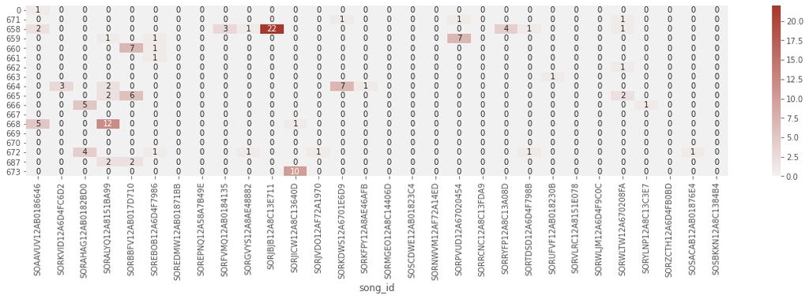

```python
#visualize the above matrix using a heatmap

# Create a mask
# mask = np.triu(np.ones_like(most_played_songs_users_selected, dtype=bool))

# Create a custom diverging palette between two HUSL colors
cmap = sns.diverging_palette(250, 15, s=75, l=40,
                             n=9, center="light", as_cmap=True)

#visualize the above matrix using a heatmap
figure = plt.figure(figsize=(20, 4))
sns.heatmap(most_played_songs_users_selected, annot=True, center=0, cmap=cmap)

# plt.figure(figsize=(16, 12))
# sns.heatmap(matrix, mask=mask, center=0, annot=True,
#              fmt='.2f', square=True, cmap=cmap)

plt.show()
```

#### Choosing optimal K

We will try different values of k and calculate the sum of squared errors (SSE) for each k, then we will use the elbow plot to choose the optimal value of k.

```python
sse = [] #Empty list to store the sum of squared errors for each value of k

for k in range(2, 15, 1):

    kmeans = KMeans(n_clusters=k, random_state=42).fit(interactions_matrix)

    sse.append(kmeans.inertia_)
```

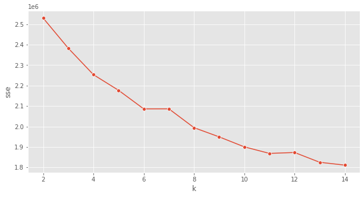

```python
#Plotting elbow plot

error_data = pd.DataFrame({'k':range(2, 15, 1), 'sse':sse})

plt.figure(figsize=(10,5))

sns.lineplot(x='k', y='sse', data=error_data, marker='o')

plt.show()
```

```python
predictions = KMeans(n_clusters=9, random_state=42).fit_predict(interactions_matrix)
results = pd.concat([most_played_songs.reset_index(), pd.DataFrame({'group':predictions})], axis=1)
results
```

|  | index | SOAAVUV12AB0186646 | SORKVID12A6D4FC6D2 | SORAHAG12AB0182BD0 | SORALYQ12A8151BA99 | SORBBFV12AB017D710 | SOREBOB12A6D4F7986 | SOREDMW12AB01871BB | SOREPNQ12A58A7B49E | SORFVMQ12AB0184135 | ... | SORUFVF12AB018230B | SORVLRC12A8151E078 | SORWLJM12A6D4F9C0C | SORWLTW12A670208FA | SORYLNP12A8C13C3E7 | SORZCTH12A6D4FB0BD | SOSACAB12AB01876E4 | SOSBKKN12A8C1384B4 | counts | group |
| --- | --- | --- | --- | --- | --- | --- | --- | --- | --- | --- | --- | --- | --- | --- | --- | --- | --- | --- | --- | --- | --- |
| 0 | 0 | 1.0 | 0.0 | 0.0 | 0.0 | 0.0 | 0.0 | 0.0 | 0.0 | 0.0 | ... | 0.0 | 0.0 | 0.0 | 0.0 | 0.0 | 0.0 | 0.0 | 0.0 | 30 | 0 |
| 1 | 1 | 0.0 | 0.0 | 0.0 | 1.0 | 3.0 | 0.0 | 0.0 | 0.0 | 0.0 | ... | 1.0 | 0.0 | 0.0 | 0.0 | 0.0 | 0.0 | 0.0 | 0.0 | 30 | 0 |
| 2 | 2 | 0.0 | 0.0 | 0.0 | 0.0 | 0.0 | 0.0 | 0.0 | 0.0 | 0.0 | ... | 0.0 | 0.0 | 0.0 | 0.0 | 0.0 | 0.0 | 0.0 | 0.0 | 30 | 8 |
| 3 | 3 | 0.0 | 0.0 | 0.0 | 1.0 | 0.0 | 0.0 | 0.0 | 0.0 | 0.0 | ... | 0.0 | 0.0 | 0.0 | 0.0 | 0.0 | 0.0 | 0.0 | 0.0 | 30 | 0 |
| 4 | 4 | 4.0 | 0.0 | 0.0 | 0.0 | 0.0 | 0.0 | 0.0 | 0.0 | 0.0 | ... | 0.0 | 0.0 | 0.0 | 5.0 | 0.0 | 0.0 | 0.0 | 0.0 | 30 | 8 |
| ... | ... | ... | ... | ... | ... | ... | ... | ... | ... | ... | ... | ... | ... | ... | ... | ... | ... | ... | ... | ... | ... |
| 995 | 995 | 0.0 | 0.0 | 0.0 | 0.0 | 0.0 | 0.0 | 0.0 | 0.0 | 0.0 | ... | 0.0 | 0.0 | 0.0 | 0.0 | 0.0 | 0.0 | 0.0 | 0.0 | 30 | 0 |
| 996 | 996 | 0.0 | 0.0 | 0.0 | 0.0 | 0.0 | 0.0 | 0.0 | 0.0 | 0.0 | ... | 0.0 | 1.0 | 0.0 | 0.0 | 0.0 | 0.0 | 0.0 | 2.0 | 30 | 0 |
| 997 | 997 | 0.0 | 0.0 | 0.0 | 0.0 | 0.0 | 0.0 | 0.0 | 0.0 | 0.0 | ... | 0.0 | 0.0 | 0.0 | 1.0 | 0.0 | 4.0 | 0.0 | 0.0 | 30 | 0 |
| 998 | 998 | 0.0 | 0.0 | 0.0 | 0.0 | 0.0 | 0.0 | 0.0 | 0.0 | 0.0 | ... | 0.0 | 0.0 | 0.0 | 0.0 | 0.0 | 0.0 | 0.0 | 0.0 | 30 | 0 |
| 999 | 999 | 0.0 | 0.0 | 0.0 | 0.0 | 0.0 | 0.0 | 0.0 | 0.0 | 1.0 | ... | 0.0 | 0.0 | 0.0 | 0.0 | 0.0 | 0.0 | 0.0 | 0.0 | 30 | 0 |

1000 rows × 33 columns

```python
print("count of user in each cluster")
results['group'].value_counts()
```

```
count of user in each cluster
```

```
0    739
8    242
6     12
4      2
1      1
2      1
3      1
5      1
7      1
Name: group, dtype: int64
```

Visualize the 6th cluster and check how sparse or dense the cluster is. It would be difficult to visualize large clusters, so let's plot only 50 users and songs with most interactions.

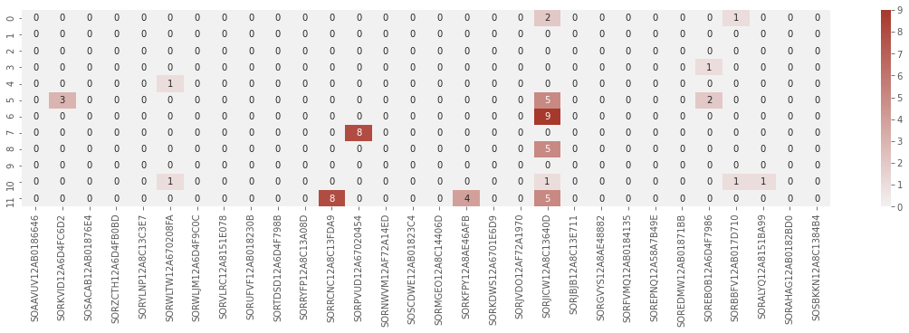

```python
cluster_number = 6
n_users = 50
n_songs = 50

#Filtering the dataframe to extract user in cluster 6
cluster_6_predictions = results[results.group == cluster_number].drop(['group', 'counts', 'index'], axis=1)

#Finding top 100 songs with most number of interactions
cluster_6_songs = find_most_played_songs(cluster_6_predictions, n_songs)

#Finding top 100 users with most number of interactions
cluster_6_users = find_most_interacted_users(cluster_6_songs, n_users)

#PLotting heatmap
figure = plt.figure(figsize=(20, 4))
sns.heatmap(cluster_6_users, annot=True, center=0, cmap=cmap)
```

The above heatmap shows that even cluster 6 is not that dense, and still includes a majority of 0s. As stated before, kmeans algorithm might not be suitable for this dataset.

### Content based recommendation system

```python
# Thses systems do not able to work efficiently with large sparse data
```

## Other evaluations and model tunings

#### Checking the dataframes' distribution

Observations & Insights:

Lets start by checking the distribution of play_count and handling its outliers.

```python
print(len(counts['play_count'].value_counts(1)))
counts['play_count'].value_counts(1)#Pandas Index.value_counts() returns counts of unique values in descending order.
```

```
295
```

```
1      5.692165e-01
2      1.565215e-01
3      7.146650e-02
5      4.656800e-02
4      4.128450e-02
           ...
260    5.000000e-07
259    5.000000e-07
255    5.000000e-07
254    5.000000e-07
920    5.000000e-07
Name: play_count, Length: 295, dtype: float64
```

```python
counts['play_count'].value_counts(1).describe().T
```

```
count    2.950000e+02
mean     3.389831e-03
std      3.476236e-02
min      5.000000e-07
25%      5.000000e-07
50%      2.500000e-06
75%      3.175000e-05
max      5.692165e-01
Name: play_count, dtype: float64
```

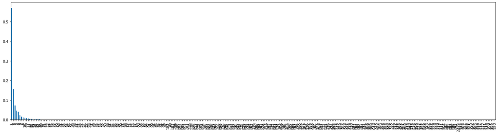

```python
# The play_count distribution plot

plt.figure(figsize = (24,6))
counts['play_count'].value_counts(1).plot(kind='bar')
plt.show()
```

- The distribution of play_count highly is skewed to the right; this could be due to having outliers.
- The count of play_count 1 is much higher than other levels which would imply that the majority of users have listened to most of the songs only once. Playing a song only once could be an indicator that the user didn't enjoy listening to that particular work much.
- The more a song was played could indicate that the more the user liked the song; We could use the number of times a song was played as a proxy to how much the user likes that type of work.

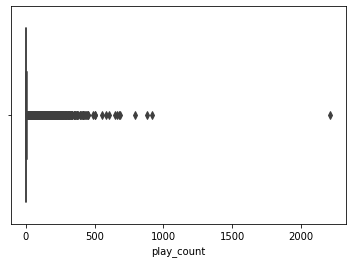

```python
ax = sns.boxplot(x=counts['play_count'])
```

- The boxplot gives us a better understanding of the outliers. These values could be replaced by a treshhold or depending on factors, such as how many they are, we could delete all of them at once.

```python
# Finding the outliers using IQR
Q1 = np.percentile(counts['play_count'], 25,
                   interpolation = 'midpoint')

Q3 = np.percentile(counts['play_count'], 75,
                   interpolation = 'midpoint')
IQR = Q3 - Q1

print("Old Shape: ", counts.shape)
print("Number of values above the Upper bound is ",len(counts[counts['play_count'] >= (Q3+1.5*IQR)]))

# Upper bound
#upper = np.where(counts[counts['play_count'] >= (Q3+1.5*IQR)])
# Lower bound
# lower = np.where(counts['play_count'] <= (Q1-1.5*IQR))

# print("Number of values below the Lower bound is ",len(lower))
print("The IQR is equal to ", int(IQR))
```

```
Old Shape:  (2000000, 3)
Number of values above the Upper bound is  229886
The IQR is equal to  2
```

```python
#Some of the outliers
counts[counts['play_count'] >= (Q3+1.5*IQR)]
```

|  | user_id | song_id | play_count |
| --- | --- | --- | --- |
| 16 | b80344d063b5ccb3212f76538f3d9e43d87dca9e | SOMGIYR12AB0187973 | 6 |
| 43 | b80344d063b5ccb3212f76538f3d9e43d87dca9e | SOYHEPA12A8C13097F | 8 |
| 58 | 969cc6fb74e076a68e36a04409cb9d3765757508 | SOBFPJC12A58A7D1AB | 9 |
| 63 | 969cc6fb74e076a68e36a04409cb9d3765757508 | SOGFUFC12A8C13F1E5 | 6 |
| 66 | 969cc6fb74e076a68e36a04409cb9d3765757508 | SONZWDK12A6701F62B | 10 |
| ... | ... | ... | ... |
| 1999942 | 276e43ad698705e5011e5091f367d951b21246f5 | SOWTYVO12AB0180BDA | 8 |
| 1999944 | 276e43ad698705e5011e5091f367d951b21246f5 | SOXJOZW12A6701E90E | 7 |
| 1999952 | d8bfd4ec88f0f3773a9e022e3c1a0f1d3b7b6a92 | SOAUWYT12A81C206F1 | 7 |
| 1999955 | d8bfd4ec88f0f3773a9e022e3c1a0f1d3b7b6a92 | SOBOUPA12A6D4F81F1 | 7 |
| 1999976 | d8bfd4ec88f0f3773a9e022e3c1a0f1d3b7b6a92 | SOFRQTD12A81C233C0 | 9 |

229886 rows × 3 columns

```python
Q3+1.5*IQR #Upper bound given by the traditional formula
```

```
6.0
```

- While it is quite reasonable of a user to play a song over 6 times, if we use the common formula, we'd wrongly classify many of the data at hand as outliers.
- To overcome this issue, we could lay a reasonable threshold ourselves or use another formula to identify the outliers.
- Below, I've used the average plus 3*std as a threshold.

```python
counts[['play_count']].mean(axis=0)+3*counts[['play_count']].std(axis=0)
```

```
play_count    22.784644
dtype: float64
```

```python
threshold = int(counts[['play_count']].mean(axis=0)+3*counts[['play_count']].std(axis=0))
print("Number of values above the chosen threshold:",len(counts[counts['play_count'] >= threshold]))
```

```
Number of values above the chosen threshold: 28487
```

```python
#len(counts[counts['play_count'] <= (Q1-1.5*IQR)]) #lower
```

[output not shown]

```python
np.where(counts['play_count'] >= threshold)[0]
```

```
array([    304,     336,     549, ..., 1999909, 1999911, 1999913],
      dtype=int64)
```

```python
''' Handling the Outliers '''
# # Lets replace the upper-end outlierst with the threshold (instead of dropping them).
# upper_threshold = np.where(counts['play_count'] >= threshold)
# counts.replace(to_replace = upper_threshold[0], value= threshold, inplace = True)
# ##resulted in MemoryError: Unable to allocate 1.91 MiB for an array with shape (1, 2000000) :(

# Due to Memory error, I need to drop the rows containing outliers
upper_threshold = np.where(counts['play_count'] >= threshold)
counts.drop(upper_threshold[0], inplace = True)

# resetting the DatFrame index (this wouldn't have been needed if we had dropped the rows containing outliers)
counts = counts.reset_index()

print("New Shape: ", counts.shape)
```

```
New Shape:  (1971513, 4)
```

```python
counts.columns
```

```
Index(['index', 'user_id', 'song_id', 'play_count'], dtype='object')
```

```python
counts.drop(['index'], axis = 1, inplace=True)
print("New Shape: ", counts.shape)
```

```
New Shape:  (1971513, 3)
```

Now lets have a look at the distribution of the year variable in the song dataframe.

```python
# Number of unique values of release year
song['year'].nunique()
```

```
90
```

```python
max(song['year'].unique())
```

```
2011
```

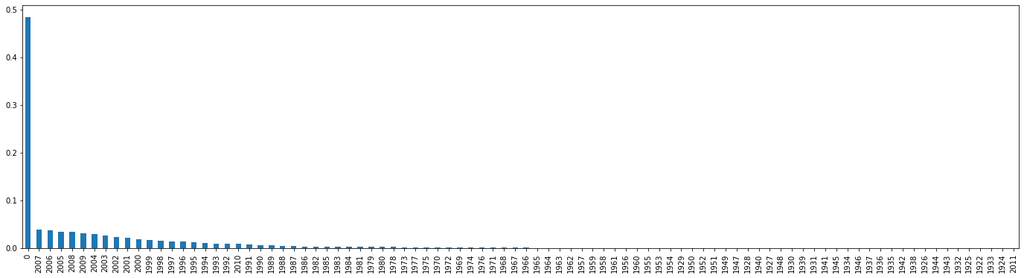

```python
# The year distribution plot sorted based on frequency of year of release values of that year

plt.figure(figsize = (24,6))
song['year'].value_counts(1).plot(kind='bar')
plt.show()
```

```python
np.sort(song['year'].unique())
```

```
array([   0, 1922, 1924, 1925, 1926, 1927, 1928, 1929, 1930, 1931, 1932,
       1933, 1934, 1935, 1936, 1937, 1938, 1939, 1940, 1941, 1942, 1943,
       1944, 1945, 1946, 1947, 1948, 1949, 1950, 1951, 1952, 1953, 1954,
       1955, 1956, 1957, 1958, 1959, 1960, 1961, 1962, 1963, 1964, 1965,
       1966, 1967, 1968, 1969, 1970, 1971, 1972, 1973, 1974, 1975, 1976,
       1977, 1978, 1979, 1980, 1981, 1982, 1983, 1984, 1985, 1986, 1987,
       1988, 1989, 1990, 1991, 1992, 1993, 1994, 1995, 1996, 1997, 1998,
       1999, 2000, 2001, 2002, 2003, 2004, 2005, 2006, 2007, 2008, 2009,
       2010, 2011], dtype=int64)
```

```python
min(song['year'].unique())
```

```
0
```

```python
song['year'].value_counts()
```

```
0       484423
2007     39414
2006     37546
2005     34960
2008     34770
         ...
1925         7
1922         6
1933         6
1924         5
2011         1
Name: year, Length: 90, dtype: int64
```

```python
song['year'].value_counts()[0]/len(song.year)
```

```
0.48442348442348443
```

The minimum value of year of release is 0, which is obviously wrong. Unfortunately as the above plot and table show, the number of rows having this value as their year is very big (484423, which is over 48% of the number of rows in this dataframe). Based on the information available we don't have any method to replace these values and unfortunately we should either drop the rows in which year is zero or drop the entire column or analyse the data applying each of these strategies independently and compare the resuls on a validation set afterwords to decide the final method to apply.

```python
# Making a copy of the song dataframe and deleting its year feature due to the high amount of wrong entries in it:
song_copy = song.copy()
song_copy.drop(['year'], inplace = True, axis = 1)
```

```python
song_copy.info()
```

```
<class 'pandas.core.frame.DataFrame'>
RangeIndex: 999999 entries, 0 to 999998
Data columns (total 3 columns):
 #   Column       Non-Null Count   Dtype
---  ------       --------------   -----
 0   song_id      999999 non-null  object
 1   release      999999 non-null  object
 2   artist_name  999999 non-null  object
dtypes: object(3)
memory usage: 22.9+ MB
```

#### Users with most diverse number of songs playyed

```python
# Top 10 users based on number of different songs they played
most_listened = counts.groupby('user_id').size().sort_values(ascending=False)[:10] #size() counts the number of elements along a given axis.
most_listened
```

```
user_id
6d625c6557df84b60d90426c0116138b617b9449    691
fbee1c8ce1a346fa07d2ef648cec81117438b91f    642
4e11f45d732f4861772b2906f81a7d384552ad12    555
24b98f8ab023f6e7a1c37c7729c623f7b821eb95    539
1aa4fd215aadb160965110ed8a829745cde319eb    531
b04e41133dd3d30a5631cc8589a1eadd48a8bd53    523
15eeb36ae1c62d60de9fdeea0d121eb7d08713be    522
a15075a926c1998d91940f118342ba8356efc7d4    500
ce5c912bb8044f23fc0fc31bd986b8d0a7303db5    489
6a9cf03dfb2fc82f5b3b043c9c3fdbab997fd54d    487
dtype: int64
```

- The highest number of diverse songs listened to by a user is 691 which is far from the actual number of songs present in the data. We can build a recommendation system to recommend to users songs, which they haven't yet tried.

### Data preparation

```python
counts['user_id'].value_counts()
```

```
6d625c6557df84b60d90426c0116138b617b9449    691
fbee1c8ce1a346fa07d2ef648cec81117438b91f    642
4e11f45d732f4861772b2906f81a7d384552ad12    555
24b98f8ab023f6e7a1c37c7729c623f7b821eb95    539
1aa4fd215aadb160965110ed8a829745cde319eb    531
                                           ...
4c2f8fd14ac74e03a4577a3d4d6bfb29dbd6c5da      1
14d4e91285a59c12f4059afa4879043869473a9e      1
d427777f72cf7d9af0b75892e89f9b37dd2c007f      1
66c75cd7a58ca33e891f3fe337f5b01ca8d551b2      1
2f85b73a02f095692cccdfa71d2664dbb27e7d4e      1
Name: user_id, Length: 76327, dtype: int64
```

**To make the dataset less sparse and easier to work with, let's take a subset of the dataset (by only keeping the users who have listened to 50 or more songs).**

```python
counts_sub = counts['user_id'].value_counts()
df_final = counts[counts['user_id'].isin(counts_sub[counts_sub >= 50].index)]
```

```python
print('The number of observations in the final data =', len(df_final))
print('Number of unique users in the final data = ', df_final['user_id'].nunique())
print('Number of unique songs in the final data = ', df_final['song_id'].nunique())
```

```
The number of observations in the final data = 865172
Number of unique users in the final data =  9801
Number of unique songs in the final data =  10000
```

- The dataframe **df_final has users who have listened to 50 or more different songs**
- It is interesting that while number of unique users decreased from 76327 in the previous data to only 9801 users, the number of unique songs didn't change.
- **We will use df_final to build recommendation systems**

#### Checking the density of the rating matrix

```python
# We handled the missing values either by replacing or dropping them previously in this notebook.
# Here we'll creat the interaction matrix of song and user based on plays, and fill them with 0, if there weren't any interactions.
final_plays_matrix = df_final.pivot(index = 'user_id', columns ='song_id', values = 'play_count').fillna(0)
print('Shape of final_plays_matrix: ', final_plays_matrix.shape)

#Finding the number of non-zero entries in the interaction matrix
given_num_of_plays = np.count_nonzero(final_plays_matrix)
print('given_num_of_plays = ', given_num_of_plays)

#Finding the possible number of plays as per the number of users and songs
possible_num_of_plays = final_plays_matrix.shape[0] * final_plays_matrix.shape[1]
print('possible_num_of_plays = ', possible_num_of_plays)

#Density of ratings
density = (given_num_of_plays/possible_num_of_plays)
density *= 100
print ('density: {:4.2f}%'.format(density))

final_plays_matrix.head()
```

```
Shape of final_plays_matrix:  (9801, 10000)
given_num_of_plays =  865172
possible_num_of_plays =  98010000
density: 0.88%
```

| song_id user_id | SOAAAGQ12A8C1420C8 | SOAACPJ12A81C21360 | SOAACSG12AB018DC80 | SOAAEJI12AB0188AB5 | SOAAFAC12A67ADF7EB | SOAAFYH12A8C13717A | SOAAJMQ12A6D4F7D17 | SOAAKPM12A58A77210 | SOAALWN12A6D4F7FDA | SOAAMOW12AB018149B | ... | SOZZKPR12A6D4F8147 | SOZZLTY12A67AE0AD0 | SOZZLZN12A8AE48D6D | SOZZRHE12A6702165F | SOZZTCU12AB0182C58 | SOZZTNF12A8C139916 | SOZZVWB12AB0189C30 | SOZZWZV12A67AE140F | SOZZYAO12A6701FF36 | SOZZZPV12A8C1444B5 |
| --- | --- | --- | --- | --- | --- | --- | --- | --- | --- | --- | --- | --- | --- | --- | --- | --- | --- | --- | --- | --- | --- |
| 000e2c2a8c7870ff9121f212b35c8b3a20cc0e67 | 0.0 | 0.0 | 0.0 | 0.0 | 0.0 | 0.0 | 0.0 | 0.0 | 0.0 | 0.0 | ... | 0.0 | 0.0 | 0.0 | 0.0 | 0.0 | 0.0 | 0.0 | 0.0 | 0.0 | 0.0 |
| 000ebc858861aca26bac9b49f650ed424cf882fc | 0.0 | 0.0 | 0.0 | 0.0 | 0.0 | 0.0 | 0.0 | 0.0 | 0.0 | 0.0 | ... | 0.0 | 0.0 | 0.0 | 0.0 | 0.0 | 0.0 | 0.0 | 0.0 | 0.0 | 0.0 |
| 00185e316f07f0f00c325ca034be59c15b362401 | 0.0 | 0.0 | 0.0 | 0.0 | 0.0 | 0.0 | 0.0 | 0.0 | 0.0 | 0.0 | ... | 0.0 | 0.0 | 0.0 | 0.0 | 0.0 | 0.0 | 0.0 | 0.0 | 0.0 | 0.0 |
| 002543003041db1d049206b09426d5cdffc0f451 | 0.0 | 0.0 | 0.0 | 0.0 | 0.0 | 0.0 | 0.0 | 0.0 | 0.0 | 0.0 | ... | 0.0 | 0.0 | 0.0 | 0.0 | 0.0 | 0.0 | 0.0 | 0.0 | 0.0 | 0.0 |
| 0028292aa536122c1f86fd48a39bd83fe582d27f | 0.0 | 0.0 | 0.0 | 0.0 | 0.0 | 0.0 | 0.0 | 0.0 | 0.0 | 0.0 | ... | 0.0 | 0.0 | 0.0 | 0.0 | 0.0 | 0.0 | 0.0 | 0.0 | 0.0 | 0.0 |

5 rows × 10000 columns

- Even with the subset of users, the current number of plays is just **0.88%** of the possible number of plays. This implies that the data is **highly sparse**.
- We will build recommendation systems to recommend products to users with which they have not interacted.

# More Clustering using merged data

### Merged Data Exploratory Data Analysis

Data Description:

```python
# number of unique users in the merged dataset
plays_with_title['user_id'].nunique()
```

```
76353
```

There are 76353 users in the merged dataset.

```python
# number of unique titles in the merged dataset
plays_with_title['title'].nunique()
```

```
9593
```

There are 9593 titles in the merged dataset.

```python
# Interaction matrix for these 671 users and 7062 movies in the dataset
interactions_matrix = pd.pivot_table(plays_with_title, index='user_id', columns= 'title', values='play_count')
interactions_matrix.head()
```

| title user_id | #!*@ You Tonight [Featuring R. Kelly] (Explicit Album Version) | #40 | & Down | ' Cello Song | '97 Bonnie & Clyde | 'Round Midnight | 'Til We Die (Album Version) | 'Till I Collapse | ('Til) I Kissed You | (Anaesthesia) Pulling Teath | ... | sillyworld (Album Version) | sleep_ eat food_ have visions | smile around the face | sun drums and soil | teachme (Album Version) | the Love Song | you were there with me | ¡Viva La Gloria! (Album Version) | ¿Lo Ves? [Piano Y Voz] | Época |
| --- | --- | --- | --- | --- | --- | --- | --- | --- | --- | --- | --- | --- | --- | --- | --- | --- | --- | --- | --- | --- | --- |
| 00003a4459f33b92906be11abe0e93efc423c0ff | NaN | NaN | NaN | NaN | NaN | NaN | NaN | NaN | NaN | NaN | ... | NaN | NaN | NaN | NaN | NaN | NaN | NaN | NaN | NaN | NaN |
| 00005c6177188f12fb5e2e82cdbd93e8a3f35e64 | NaN | NaN | NaN | NaN | NaN | NaN | NaN | NaN | NaN | NaN | ... | NaN | NaN | NaN | NaN | NaN | NaN | NaN | NaN | NaN | NaN |
| 00030033e3a2f904a48ec1dd53019c9969b6ef1f | NaN | NaN | NaN | NaN | NaN | NaN | NaN | NaN | NaN | NaN | ... | NaN | NaN | NaN | NaN | NaN | NaN | NaN | NaN | NaN | NaN |
| 0007235c769e610e3d339a17818a5708e41008d9 | NaN | NaN | NaN | NaN | NaN | NaN | NaN | NaN | NaN | NaN | ... | NaN | NaN | NaN | NaN | NaN | NaN | NaN | NaN | NaN | NaN |
| 0007c0e74728ca9ef0fe4eb7f75732e8026a278b | NaN | NaN | NaN | NaN | NaN | NaN | NaN | NaN | NaN | NaN | ... | NaN | NaN | NaN | NaN | NaN | NaN | NaN | NaN | NaN | NaN |

5 rows × 9593 columns

As per the number of unique users and songs, there is a possibility of 76353 * 9593 = 732,454,329 play counts in the dataset. But we only have 2,086,946 play counts, that's why we are getting a sparse user movie interactions matrix above with the majority of the values being NaN. We can build a recommendation system to recommend songs to users which they have not interacted with.

To create a dense version of the above matrix, let's sort by the most rated songs, and the users who have played the most number of songs.

```python
def find_most_played_songs(interactions_matrix, num_songs):

    #Appending the count of plays for each song as a row in the interaction matrix
    user_song_plays = interactions_matrix.append(interactions_matrix.count(), ignore_index=True)

    #Sorting the values in the interaction matrix on the basis of the appended row
    user_song_plays_sorted = user_song_plays.sort_values(user_song_plays.shape[0]-1, axis=1, ascending=False)

    #Dropping the appended row from the sorted interaction matrix
    user_song_plays_sorted.drop(user_song_plays_sorted.tail(1).index, inplace=True)

    #Selecting top songs with the most number of ratings
    most_played_songs = user_song_plays_sorted.iloc[:, :num_songs]

    return most_played_songs
```

```python
 #Finding 30 most rated movies
most_played_songs = find_most_played_songs(interactions_matrix, 30)
most_played_songs
```

| title | Sehr kosmisch | Undo | Dog Days Are Over (Radio Edit) | You're The One | Revelry | Secrets | Horn Concerto No. 4 in E flat K495: II. Romance (Andante cantabile) | Fireflies | Hey_ Soul Sister | Tive Sim | ... | Sincerité Et Jalousie | Billionaire [feat. Bruno Mars] (Explicit Album Version) | Just Dance | Représente | Alejandro | Lucky (Album Version) | Somebody To Love | Invalid | Ain't Misbehavin | Creep (Explicit) |
| --- | --- | --- | --- | --- | --- | --- | --- | --- | --- | --- | --- | --- | --- | --- | --- | --- | --- | --- | --- | --- | --- |
| 0 | NaN | NaN | NaN | NaN | NaN | NaN | NaN | NaN | NaN | NaN | ... | NaN | NaN | NaN | NaN | NaN | NaN | NaN | NaN | NaN | NaN |
| 1 | NaN | NaN | NaN | NaN | NaN | NaN | NaN | NaN | NaN | NaN | ... | NaN | NaN | NaN | NaN | NaN | NaN | NaN | NaN | NaN | NaN |
| 2 | NaN | NaN | NaN | 2.0 | NaN | 7.0 | NaN | NaN | NaN | NaN | ... | NaN | NaN | NaN | NaN | NaN | NaN | NaN | NaN | NaN | NaN |
| 3 | NaN | NaN | NaN | NaN | NaN | NaN | NaN | NaN | NaN | NaN | ... | NaN | NaN | NaN | NaN | NaN | NaN | NaN | NaN | NaN | NaN |
| 4 | NaN | NaN | NaN | NaN | NaN | NaN | NaN | NaN | NaN | NaN | ... | NaN | NaN | NaN | NaN | NaN | NaN | NaN | NaN | NaN | NaN |
| ... | ... | ... | ... | ... | ... | ... | ... | ... | ... | ... | ... | ... | ... | ... | ... | ... | ... | ... | ... | ... | ... |
| 76348 | NaN | 4.0 | 1.0 | 4.0 | 2.0 | NaN | 2.0 | NaN | NaN | 5.0 | ... | 1.0 | NaN | NaN | 1.0 | NaN | NaN | NaN | 1.0 | 1.0 | NaN |
| 76349 | NaN | NaN | NaN | NaN | NaN | NaN | NaN | NaN | NaN | NaN | ... | NaN | NaN | NaN | NaN | NaN | NaN | NaN | NaN | NaN | NaN |
| 76350 | NaN | NaN | NaN | NaN | NaN | NaN | NaN | NaN | NaN | NaN | ... | NaN | NaN | NaN | NaN | NaN | NaN | NaN | NaN | NaN | NaN |
| 76351 | NaN | NaN | NaN | NaN | 1.0 | NaN | NaN | NaN | NaN | NaN | ... | NaN | NaN | NaN | NaN | NaN | NaN | NaN | NaN | NaN | NaN |
| 76352 | NaN | NaN | NaN | NaN | NaN | NaN | NaN | NaN | NaN | NaN | ... | NaN | NaN | NaN | NaN | NaN | NaN | NaN | NaN | NaN | NaN |

76353 rows × 30 columns

```python
def find_most_interacted_users(most_played_songs, num_users):

    #Finding how many of the top 30 songs have been played by the user
    most_played_songs['counts'] = pd.Series(most_played_songs.count(axis=1))

    #Sorting the dataframe by the new 'counts' columns
    most_played_songs_users = most_played_songs.sort_values('counts', ascending=False)

    #Selecting top users with the most number of interactions
    most_played_songs_users_selected = most_played_songs_users.iloc[:num_users, :]

    #Dropping the 'counts' column
    most_played_songs_users_selected.drop(['counts'], axis=1, inplace=True)

    return most_played_songs_users_selected
```

```python
#Finding top 18 users with the most number of interactions
most_played_songs_users_selected = find_most_interacted_users(most_played_songs, 18)
most_played_songs_users_selected
```

| title | Sehr kosmisch | Undo | Dog Days Are Over (Radio Edit) | You're The One | Revelry | Secrets | Horn Concerto No. 4 in E flat K495: II. Romance (Andante cantabile) | Fireflies | Hey_ Soul Sister | Tive Sim | ... | Sincerité Et Jalousie | Billionaire [feat. Bruno Mars] (Explicit Album Version) | Just Dance | Représente | Alejandro | Lucky (Album Version) | Somebody To Love | Invalid | Ain't Misbehavin | Creep (Explicit) |
| --- | --- | --- | --- | --- | --- | --- | --- | --- | --- | --- | --- | --- | --- | --- | --- | --- | --- | --- | --- | --- | --- |
| 72833 | 14.0 | 19.0 | 17.0 | 20.0 | 13.0 | 8.0 | 29.0 | 7.0 | 11.0 | 1.0 | ... | 3.0 | 2.0 | 2.0 | 8.0 | 3.0 | 4.0 | 4.0 | 7.0 | 9.0 | 1.0 |
| 69921 | 2.0 | 8.0 | 2.0 | 8.0 | 7.0 | 3.0 | 4.0 | 2.0 | 2.0 | 3.0 | ... | 1.0 | 3.0 | 3.0 | 3.0 | 3.0 | 3.0 | 3.0 | 8.0 | 6.0 | 3.0 |
| 69612 | 10.0 | 12.0 | 8.0 | 11.0 | 11.0 | 7.0 | 8.0 | 6.0 | 5.0 | 2.0 | ... | 5.0 | 2.0 | 2.0 | 6.0 | 2.0 | 2.0 | 4.0 | 39.0 | 5.0 | 4.0 |
| 59974 | 8.0 | 19.0 | 12.0 | 27.0 | 8.0 | 8.0 | 5.0 | 22.0 | 19.0 | 2.0 | ... | 24.0 | 12.0 | 4.0 | 17.0 | 5.0 | 28.0 | 5.0 | 11.0 | 13.0 | 2.0 |
| 3237 | 157.0 | 44.0 | 10.0 | 43.0 | 36.0 | 35.0 | 28.0 | 4.0 | 5.0 | 16.0 | ... | 24.0 | 9.0 | 3.0 | 25.0 | 156.0 | 156.0 | 4.0 | 24.0 | 18.0 | 4.0 |
| 23337 | 7.0 | 26.0 | 5.0 | 20.0 | 18.0 | 5.0 | 14.0 | 5.0 | 4.0 | 3.0 | ... | 18.0 | 4.0 | 4.0 | 15.0 | 3.0 | 5.0 | 4.0 | 9.0 | 8.0 | 3.0 |
| 10615 | 6.0 | 35.0 | 15.0 | 17.0 | 14.0 | 7.0 | 4.0 | 5.0 | 6.0 | 4.0 | ... | 2.0 | 4.0 | 9.0 | 10.0 | 1.0 | 5.0 | 7.0 | 12.0 | 4.0 | 2.0 |
| 3128 | 31.0 | 56.0 | 29.0 | 54.0 | 47.0 | 26.0 | 75.0 | 22.0 | 20.0 | 21.0 | ... | 14.0 | 4.0 | 7.0 | 15.0 | 10.0 | 11.0 | 13.0 | 23.0 | 14.0 | 3.0 |
| 7401 | 3.0 | 13.0 | 1.0 | 13.0 | 12.0 | 1.0 | 8.0 | 1.0 | 3.0 | 1.0 | ... | 12.0 | 1.0 | 1.0 | 8.0 | 1.0 | 1.0 | 1.0 | 20.0 | 8.0 | 1.0 |
| 62472 | 4.0 | 13.0 | 3.0 | 17.0 | 8.0 | 5.0 | 11.0 | 2.0 | 3.0 | 7.0 | ... | 13.0 | 2.0 | 1.0 | 4.0 | 3.0 | 3.0 | 3.0 | 9.0 | 7.0 | 1.0 |
| 36015 | 6.0 | 6.0 | 7.0 | 6.0 | 5.0 | 6.0 | 6.0 | 5.0 | 3.0 | 1.0 | ... | 1.0 | 7.0 | 2.0 | 1.0 | 8.0 | 2.0 | 2.0 | 6.0 | 5.0 | 1.0 |
| 47578 | 19.0 | 38.0 | 24.0 | 51.0 | 42.0 | 16.0 | 38.0 | 9.0 | 11.0 | 8.0 | ... | 9.0 | 3.0 | 2.0 | 12.0 | 5.0 | 7.0 | 10.0 | 14.0 | 35.0 | 1.0 |
| 14416 | 9.0 | 5.0 | 7.0 | 5.0 | 6.0 | 9.0 | 3.0 | 3.0 | 4.0 | 1.0 | ... | 1.0 | 2.0 | 2.0 | 1.0 | 2.0 | 2.0 | 3.0 | 1.0 | 3.0 | 2.0 |
| 36067 | 10.0 | 26.0 | 28.0 | 20.0 | 34.0 | 14.0 | 32.0 | 3.0 | 6.0 | 11.0 | ... | 1.0 | 2.0 | 2.0 | 27.0 | 2.0 | 1.0 | 4.0 | 24.0 | 15.0 | 4.0 |
| 8194 | 6.0 | 22.0 | 6.0 | 15.0 | 11.0 | 9.0 | 14.0 | 4.0 | 5.0 | 6.0 | ... | 10.0 | 2.0 | 2.0 | 11.0 | 4.0 | 4.0 | 4.0 | 12.0 | NaN | 1.0 |
| 61082 | 6.0 | 10.0 | 6.0 | 8.0 | 6.0 | 4.0 | 2.0 | 4.0 | 6.0 | 2.0 | ... | 14.0 | 2.0 | 4.0 | 2.0 | 7.0 | 3.0 | 3.0 | 3.0 | NaN | 1.0 |
| 61472 | 1.0 | 14.0 | 3.0 | 13.0 | 8.0 | 2.0 | 7.0 | 1.0 | 1.0 | 1.0 | ... | 1.0 | 2.0 | 2.0 | 2.0 | 2.0 | 1.0 | 1.0 | 1.0 | NaN | 1.0 |
| 52248 | 9.0 | 9.0 | 7.0 | 9.0 | 5.0 | 7.0 | 7.0 | 4.0 | 2.0 | 8.0 | ... | 2.0 | 1.0 | 1.0 | 4.0 | 2.0 | 1.0 | 2.0 | 6.0 | 2.0 | NaN |

18 rows × 30 columns

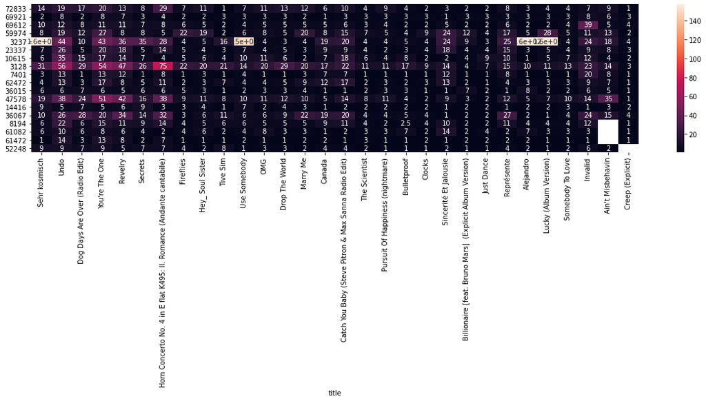

```python
# Visualize the above matrix using a heatmap
figure = plt.figure(figsize=(20, 4))
sns.heatmap(most_played_songs_users_selected, annot=True);
```

In the above heatmap, you can see that some cells are white i.e. the respective user did not play that song. Those are represented by NaN in the interactions matrix. Here, we only used 30 songs, but if we use all the songs then the number of missing ratings will also increase and it will make the interactions matrix a very sparse one.

Clustering for a matrix with a lot of missing values is a challenging task. So below we will limit our interactions matrix by only using 1000 most played songs.

```python
most_played_songs_1k = find_most_played_songs(interactions_matrix, 1000)
most_played_songs_1k
```

| title | Sehr kosmisch | Undo | Dog Days Are Over (Radio Edit) | You're The One | Revelry | Secrets | Horn Concerto No. 4 in E flat K495: II. Romance (Andante cantabile) | Fireflies | Hey_ Soul Sister | Tive Sim | ... | Neighborhood #1 (Tunnels) | Im Not The One | Nearly Home | Everybody Wants To Rule The World | Big Idea | Amy Amy Amy / Outro | Pork And Beans | The General | Rain Is A Good Thing | Make It Mine (Album Version) |
| --- | --- | --- | --- | --- | --- | --- | --- | --- | --- | --- | --- | --- | --- | --- | --- | --- | --- | --- | --- | --- | --- |
| 0 | NaN | NaN | NaN | NaN | NaN | NaN | NaN | NaN | NaN | NaN | ... | NaN | NaN | NaN | NaN | NaN | NaN | NaN | NaN | NaN | NaN |
| 1 | NaN | NaN | NaN | NaN | NaN | NaN | NaN | NaN | NaN | NaN | ... | NaN | NaN | NaN | NaN | NaN | NaN | NaN | NaN | NaN | NaN |
| 2 | NaN | NaN | NaN | 2.0 | NaN | 7.0 | NaN | NaN | NaN | NaN | ... | NaN | NaN | NaN | NaN | NaN | NaN | NaN | NaN | NaN | NaN |
| 3 | NaN | NaN | NaN | NaN | NaN | NaN | NaN | NaN | NaN | NaN | ... | NaN | NaN | NaN | NaN | NaN | NaN | NaN | NaN | NaN | NaN |
| 4 | NaN | NaN | NaN | NaN | NaN | NaN | NaN | NaN | NaN | NaN | ... | NaN | NaN | NaN | NaN | NaN | NaN | NaN | NaN | NaN | NaN |
| ... | ... | ... | ... | ... | ... | ... | ... | ... | ... | ... | ... | ... | ... | ... | ... | ... | ... | ... | ... | ... | ... |
| 76348 | NaN | 4.0 | 1.0 | 4.0 | 2.0 | NaN | 2.0 | NaN | NaN | 5.0 | ... | NaN | NaN | NaN | NaN | NaN | NaN | NaN | NaN | NaN | NaN |
| 76349 | NaN | NaN | NaN | NaN | NaN | NaN | NaN | NaN | NaN | NaN | ... | NaN | NaN | NaN | NaN | NaN | NaN | NaN | NaN | NaN | NaN |
| 76350 | NaN | NaN | NaN | NaN | NaN | NaN | NaN | NaN | NaN | NaN | ... | NaN | NaN | NaN | NaN | NaN | NaN | NaN | NaN | NaN | NaN |
| 76351 | NaN | NaN | NaN | NaN | 1.0 | NaN | NaN | NaN | NaN | NaN | ... | NaN | NaN | NaN | NaN | NaN | NaN | NaN | NaN | NaN | NaN |
| 76352 | NaN | NaN | NaN | NaN | NaN | NaN | NaN | NaN | NaN | NaN | ... | NaN | NaN | NaN | NaN | NaN | NaN | NaN | NaN | NaN | NaN |

76353 rows × 1000 columns

There are still a lot of missing values in the data. We need to replace them with 0 otherwise, we cannot build the clustering-based model. Also, we can see that the matrix is still sparse. We can save it in a compressed format for sparse matrices to reduce the size of the matrix and consequently reducing the computation time.

```python
#Filling missing values and storing the matrix as a sparse matrix
sparse_plays = csr_matrix(most_played_songs_1k.fillna(value=0))
sparse_plays
```

```
<76353x1000 sparse matrix of type '<class 'numpy.float64'>'
	with 801375 stored elements in Compressed Sparse Row format>
```

**Cluster Based Recommendation System

We will try different values of k and calculate the sum of squared errors (SSE) for each k, then we will use the elbow plot to choose the optimal value of k:

```python
sse = []

for k in range(2, 50, 5):
    kmeans = KMeans(n_clusters=k, random_state=0).fit(sparse_plays)
    sse.append(kmeans.inertia_)
```

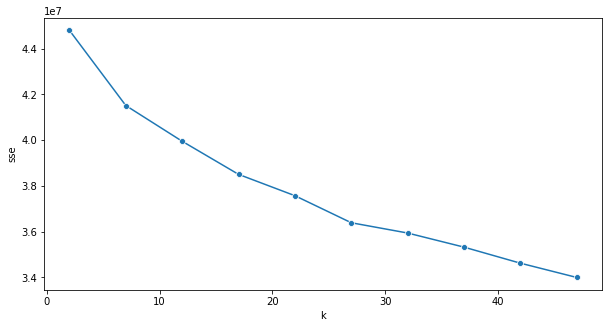

```python
#Plotting elbow plot

error_data = pd.DataFrame({'k':range(2, 50, 5), 'sse':sse})

plt.figure(figsize=(10,5))

sns.lineplot(x='k', y='sse', data=error_data, marker='o')

plt.show()
```

From the above plot, we can see there is a sharp decrease in inertia at k=7. So, we will take k=7 to create the clusters of similar users.

Now, let's cluster each user using K-Means clustering with k=7. We will add one column group with cluster labels to the original data most_played_movies_1k for each user.

```python
predictions = KMeans(n_clusters=7, random_state=0).fit_predict(sparse_plays)
results = pd.concat([most_played_songs_1k.reset_index(drop=True), pd.DataFrame({'group':predictions})], axis=1)
results
```

|  | Sehr kosmisch | Undo | Dog Days Are Over (Radio Edit) | You're The One | Revelry | Secrets | Horn Concerto No. 4 in E flat K495: II. Romance (Andante cantabile) | Fireflies | Hey_ Soul Sister | Tive Sim | ... | Im Not The One | Nearly Home | Everybody Wants To Rule The World | Big Idea | Amy Amy Amy / Outro | Pork And Beans | The General | Rain Is A Good Thing | Make It Mine (Album Version) | group |
| --- | --- | --- | --- | --- | --- | --- | --- | --- | --- | --- | --- | --- | --- | --- | --- | --- | --- | --- | --- | --- | --- |
| 0 | NaN | NaN | NaN | NaN | NaN | NaN | NaN | NaN | NaN | NaN | ... | NaN | NaN | NaN | NaN | NaN | NaN | NaN | NaN | NaN | 1 |
| 1 | NaN | NaN | NaN | NaN | NaN | NaN | NaN | NaN | NaN | NaN | ... | NaN | NaN | NaN | NaN | NaN | NaN | NaN | NaN | NaN | 1 |
| 2 | NaN | NaN | NaN | 2.0 | NaN | 7.0 | NaN | NaN | NaN | NaN | ... | NaN | NaN | NaN | NaN | NaN | NaN | NaN | NaN | NaN | 1 |
| 3 | NaN | NaN | NaN | NaN | NaN | NaN | NaN | NaN | NaN | NaN | ... | NaN | NaN | NaN | NaN | NaN | NaN | NaN | NaN | NaN | 1 |
| 4 | NaN | NaN | NaN | NaN | NaN | NaN | NaN | NaN | NaN | NaN | ... | NaN | NaN | NaN | NaN | NaN | NaN | NaN | NaN | NaN | 1 |
| ... | ... | ... | ... | ... | ... | ... | ... | ... | ... | ... | ... | ... | ... | ... | ... | ... | ... | ... | ... | ... | ... |
| 76348 | NaN | 4.0 | 1.0 | 4.0 | 2.0 | NaN | 2.0 | NaN | NaN | 5.0 | ... | NaN | NaN | NaN | NaN | NaN | NaN | NaN | NaN | NaN | 1 |
| 76349 | NaN | NaN | NaN | NaN | NaN | NaN | NaN | NaN | NaN | NaN | ... | NaN | NaN | NaN | NaN | NaN | NaN | NaN | NaN | NaN | 1 |
| 76350 | NaN | NaN | NaN | NaN | NaN | NaN | NaN | NaN | NaN | NaN | ... | NaN | NaN | NaN | NaN | NaN | NaN | NaN | NaN | NaN | 1 |
| 76351 | NaN | NaN | NaN | NaN | 1.0 | NaN | NaN | NaN | NaN | NaN | ... | NaN | NaN | NaN | NaN | NaN | NaN | NaN | NaN | NaN | 1 |
| 76352 | NaN | NaN | NaN | NaN | NaN | NaN | NaN | NaN | NaN | NaN | ... | NaN | NaN | NaN | NaN | NaN | NaN | NaN | NaN | NaN | 1 |

76353 rows × 1001 columns

```python
# Number of users in each cluster
results['group'].value_counts()
```

```
1    72770
0     3104
2      284
3      144
4       49
5        1
6        1
Name: group, dtype: int64
```

The number of users is unevenly distributed. Cluster 1 is the group with the majority of users and clusters 5 and 6 only have a single user each, which is somehow not acceptable. The smaller groups might contain clusters who have a different or very specific taste. We will not go in-depth for each cluster, but we can try to visualize the 1st cluster as it is the biggest cluster and check how sparse or dense the cluster is. It would be difficult to visualize large clusters, so let's plot only 50 users and songs with most interactions.

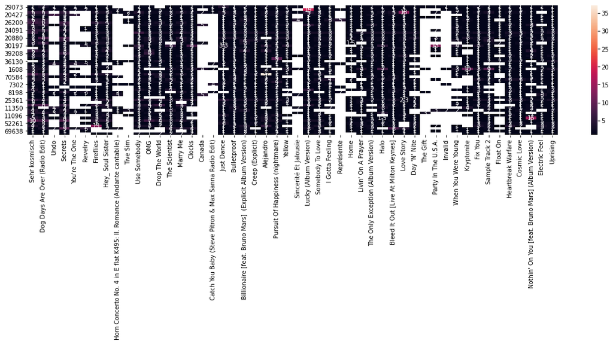

```python
cluster_number = 1
n_users = 50
n_songs = 50

#Filtering the dataframe to extract user in cluster 1
cluster_1_predictions = results[results.group == cluster_number].drop(['group'], axis=1)

#Finding top 100 songs with most number of interactions
cluster_1_songs = find_most_played_songs(cluster_1_predictions, n_songs)

#Finding top 100 users with most number of interactions
cluster_1_users = find_most_interacted_users(cluster_1_songs, n_users)

#PLotting heatmap
figure = plt.figure(figsize=(20, 4))
sns.heatmap(cluster_1_users, annot=True);
```

- Some songs/members of user in cluster 1 users have a lot of NaN values.
- The majority of songs have been played less than 8 times by user in cluster 1.